Motives and Ideology[Source code ↗](https://github.com/michaelzehetleitner/social-motives-ideology)

# Motives and Ideology: Bischof’s Zürich Model of Social Motivation, Right-wing Authoritarianism and Social Dominance Orientation

Preregistration Analysis Pipeline: Methods and Results on Synthetic Data

Published

2026-10-09

Michael Zehetleitner* — https://orcid.org/0000-0003-3363-2680  
Chiara Castiglione* — https://orcid.org/0009-0009-5005-5054  
Jana Drastik* — https://orcid.org/0009-0001-3055-4384  
Delilah Matterstock* — https://orcid.org/0009-0004-0627-1802  
Nicolas Prell* — https://orcid.org/0009-0006-3569-979X

* General Psychology, Catholic University Eichstätt-Ingolstadt, Germany

Preregistration (HTML) · [Analysis code and materials](https://github.com/michaelzehetleitner/social-motives-ideology)

Preregistration (PsychArchives): https://doi.org/10.23668/psycharchives.22601.

# 1 Introduction

This report verifies that the preregistered analysis pipeline works and that it produces the statistical measures required to answer the research questions of the preregistration:

- RQ1 — Social motives and authoritarian facet associations: to estimate each motive’s association with each authoritarian facet, conditional on the other motives and demographics.
- RQ2 — Motivational organisation of authoritarian orientation: to compare the strength and direction of each motive’s associations across facets and estimate the associations between facets and between ASC total and SDO-D conditional on all social motives and demographics, compare them with their joint-model zero-order associations, and compare each motive’s association with the equal-weight ASC total with its associations with the three ASC facets.
- RQ3 — Conditional organisation of the motive–orientation system: to examine which pairs remain associated conditional on every other variable in a Bayesian network.
- SRQ1 — Dimensionality and correspondence of item sets of authoritarian orientation and social motives: to examine how many dimensions the item sets suggest and how well the estimated item groupings correspond to the theoretical grouping.

This report presents results from synthetic preregistration data. It will be the basis for the report in the final manuscript. This approach has two consequences. First, the numbers in this report are not findings: they show that the preregistered analyses run and produce the measures the research questions need. Second, the present Methods and Discussion are shaped to the synthetic-data approach; the manuscript will not contain them. For the manuscript, the Results and the tables and figures of the appendix and supplement will be computed again from the survey responses.

# 2 Methods

The analyses are those of the analysis plan of the preregistration (Zehetleitner et al., 2026); each research question below quotes its method from there. This section describes what belongs to this run alone: the synthetic data, the software, how to reproduce the results and the settings of this run.

## 2.1 Synthetic Preregistration Data

The synthetic preregistration data are artificial survey responses generated from values set in advance. They have the same format as the empirical survey data: the questions, the six answer categories and the survey-flow fields of the survey export.

There are 776 synthesised participants; for 26 of them the quota was full. Of the remaining 750, 44 are excluded as planned: 6 refused consent, 14 did not finish, 4 were under 18, and 20 failed an attention check. The 6 who gave a gender-diverse response are excluded too, because fewer than 30 did so; that leaves 700 for the analyses.

The five motive scores were drawn from a multivariate normal distribution with correlations from −.05 to .45; age, gender and income were drawn with small correlations to the motives. Each authoritarian facet depends on the motives and the demographics:

$$\begin{aligned}
\text{authoritarian facet} = {} & \beta_{1}\,\text{security} + \beta_{2}\,\text{arousal} + \beta_{3}\,\text{power} + \beta_{4}\,\text{prestige} + \beta_{5}\,\text{achievement} \\
& + \beta_{6}\,\text{age} + \beta_{7}\,\text{gender} + \beta_{8}\,\text{income} + \varepsilon
\end{aligned}$$

The residuals $\varepsilon$ of the four facets correlate from .15 to .45. Of the 32 coefficients $\beta$, 19 are zero; the others are 0.12 to 0.25 in absolute value for the motives, 0.15 for age on conventionalism, and 0.20 and 0.35 for men on ASC aggression and SDO-D. The draws were adjusted so that these correlations and coefficients hold exactly.

Each of the 57 items reflects one of the nine scores, the five motives and the four facets:

$$\text{item} = \operatorname{round}\bigl(\text{level} + 1.05\,(0.65\,\text{score} + \sqrt{1 - 0.65^2}\, e)\bigr), \quad \text{limited to } 1\text{–}6$$

where level is the scale’s typical position on the answer scale (2.5 to 4.6) and $e$ is standard normal noise. The factor structure is thus nine correlated factors, with each item loading on exactly one, except the one described next.

For one item, conventionalism item 3, a cross-loading was planted: it loads on both conventionalism and ASC submission,

$$\text{item} = \operatorname{round}\Bigl(\text{level} + 1.05\,\frac{0.65\,\text{conventionalism} + 0.65\,\text{ASC submission} + \sqrt{1 - 0.65^2}\, e}{\sqrt{v}}\Bigr), \quad v = 1 + 0.65^2 + 2 \cdot 0.65^2\, r$$

where $r$ = .48 is the correlation of the two scores in the generated data. Dividing by $\sqrt{v}$ gives the item the same spread as the others and a standardised loading of .48 on each factor.

Problems were planted in the data to test the preregistered rules for handling such cases: respondents for every exclusion criterion except an age above 69, missing answers, a respondent without a gender entry, an item that also loads on a second scale, and a facet with heavy-tailed residuals.

## 2.2 Software

All analyses ran in R 4.5.2. The regressions were fitted with brms 2.23.0 through cmdstanr 0.9.0.9002 and CmdStan 2.36.0; the other analyses used lavaan 0.7.2, psych 2.6.5, easybgm 0.4.0, BDgraph 2.74, priorsense 1.2.0 and BayesFactor 0.9.12-4.8.

The results were produced by the analysis code at commit aab2195 (aab2195d5402c23b93bbabf07ba8fab6ba3def62), with changes to the analysis code that are not in that commit, on the synthetic preregistration data. The lockfile `renv.lock`, the analysis plan `config/analysis_plan.yaml` and the input data `data/intake/synthetic.csv` are identified by the first twelve characters of their SHA-256 fingerprints, 3b8dbce9a43f, b30107366c4d and fca1016909e7.

## 2.3 Reproducing the Results

The analysis is organised as a pipeline with the targets package (version 1.12.0). The commands in the repository reproduce the report from saved results, refit the models using saved resampling results, or repeat all analyses and simulations from the prepared data. The renv package records the version of every R package in a lockfile, so the same package library can be restored. A Docker image fixes the operating system and the versions of R, CmdStan and Quarto and installs the locked packages, so the whole analysis runs from a fresh copy of the repository. The [Code Browser](https://michaelzehetleitner.github.io/social-motives-ideology/preregistration-v1-doi/code-browser.html), generated from the code itself, shows the pipeline in three looks: every step in the order in which it runs; the documented settings and the code of each function a step calls; and the functions those call in turn.

## 2.4 Settings of This Run

This run used reduced computational settings, so that the whole pipeline finishes in minutes: 60 instead of the preregistered 1,000 bootstrap resamples for the interval of ω; an effective-sample-size target of 2,000 instead of 10,000 for every regression coefficient; and 60 network resamples of 3,000 iterations each instead of 600 of 50,000; and 1,000 iterations per regression chain after 500 warm-up instead of the preregistered 6,000 after 2,000 (AP6). The report on the empirical survey data will use the preregistered settings. When this report was rendered, every stored result it reads was current: no code or input behind them had changed since they were computed. Rendering does not recompute results.

Gender entered every regression of RQ1 and RQ2 as a factor with the levels female (364 respondents) and male (335 respondents); the reference group is female, the largest group (AP3, AP6).

# 3 Results

## 3.1 Sample

**Synthetic results.** 776 synthetic people started the survey; for 26 of them the political-leaning quota cell was already full, and the survey ended before the questionnaire. Of the remaining 750, 50 were excluded for no consent (6), incomplete response (14), age below 18 or above 69 (4), attention check 1 failed (12), attention check 2 failed (8), gender-diverse responses below the minimum of 30 (6), more than two items missing within any scale, or at least two of age, household size and income band (0), leaving an analysis sample of *N* = 700 (Table 1). One case had missing gender and was excluded from every regression of RQ1 and RQ2. Reliability, factor structure, descriptive statistics and the network use the analysis sample of *N* = 700; every regression of RQ1 and RQ2 uses *N* = 699. Participation rate is unknown, because the number of invited panel members is unknown. (M4) 9 missing values were filled using imputation models that passed the AP3 validity gate. The completed values are treated as fixed in subsequent analyses (for details see Supplement).

Table 1 describes the analysis sample by gender, school education, region, quota group, age and income.

Table 1: Sample characteristics.

Characteristic

Group

n (%) or *M* (*SD*)

Distribution

Gender

female

364 (52.0%)

male

335 (47.9%)

(missing)

1 (0.1%)

School education

No school-leaving certificate

16 (2.3%)

Lower secondary certificate (Hauptschulabschluss, 8th/9th grade)

133 (19.0%)

Intermediate secondary certificate (Realschulabschluss/Mittlere Reife, 10th grade)

255 (36.4%)

Entrance qualification for universities of applied sciences (Fachhochschulreife)

86 (12.3%)

University entrance qualification (Abitur/Hochschulreife)

199 (28.4%)

Still at school

11 (1.6%)

East/West

west

578 (82.6%)

east

122 (17.4%)

Quota group

left-leaning

234 (33.4%)

conservative-leaning

213 (30.4%)

mixed

253 (36.1%)

Age (years)

46.4 (14.3)

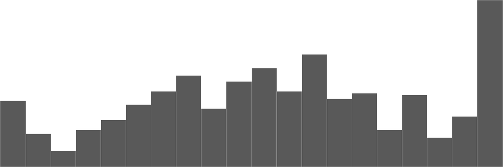

Net household income per person

1,781 (1,635)

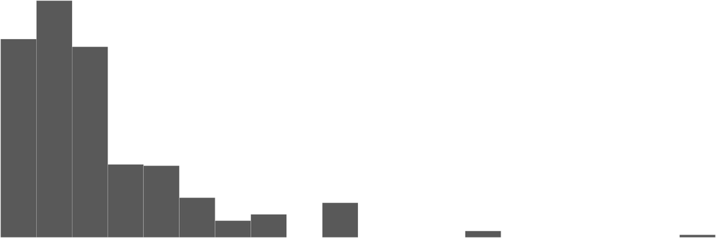

Voting intention

Yes

584 (83.4%)

No

101 (14.4%)

Missing

15 (2.1%)

Party choice

CDU/CSU

175 (25.0%)

SPD

120 (17.1%)

FDP

27 (3.9%)

The Greens

76 (10.9%)

The Left

49 (7.0%)

AfD

67 (9.6%)

Sahra Wagenknecht Alliance (BSW)

35 (5.0%)

Other party

27 (3.9%)

Invalid vote

8 (1.1%)

Party sympathy

SPD

−0.37 (1.58)

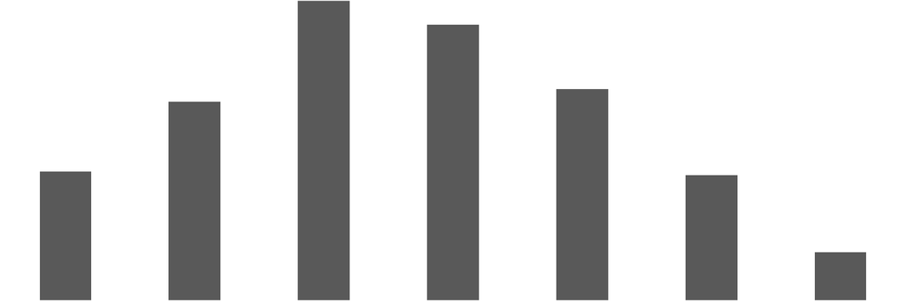

CDU/CSU

−0.18 (1.55)

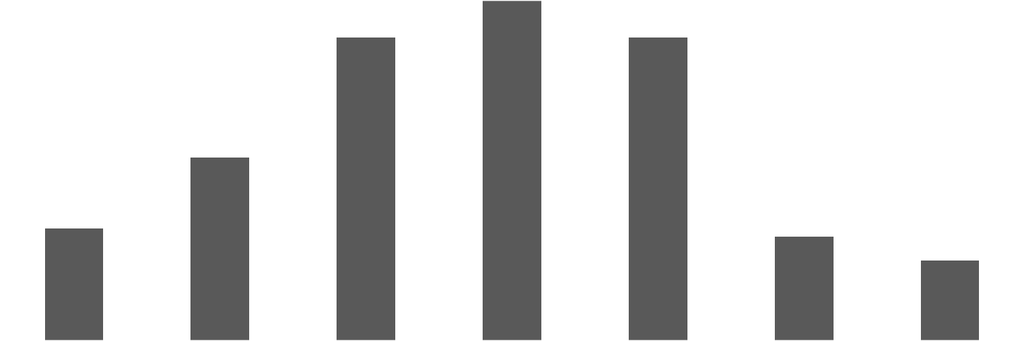

The Greens

−0.64 (1.44)

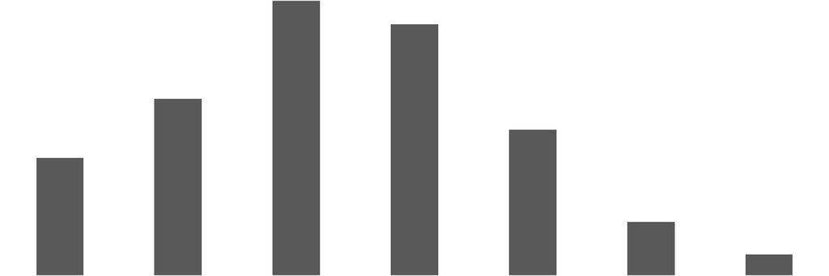

FDP

−0.78 (1.53)

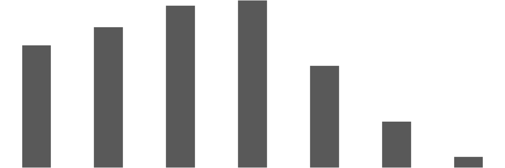

AfD

−1.43 (1.34)

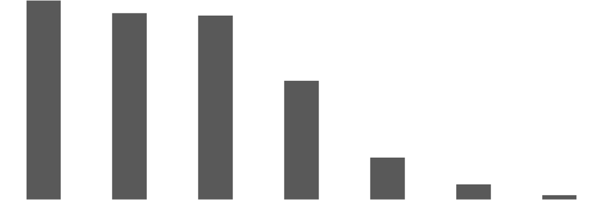

The Left

−0.81 (1.48)

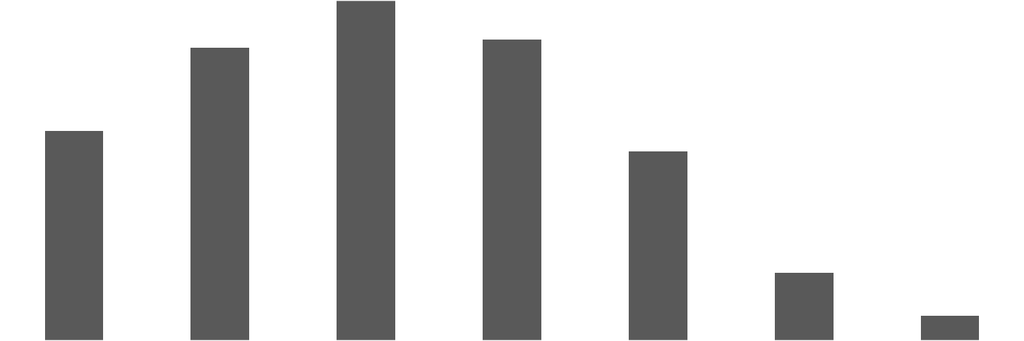

Left–right placement

5.03 (1.91)

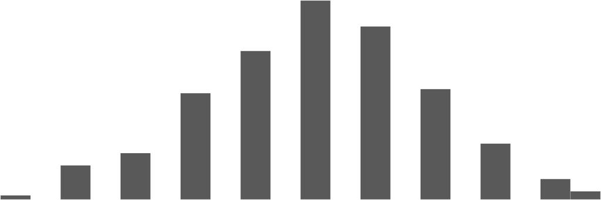

*Note.* Percentages refer to the analysis sample. Party choice was asked only after Yes to voting intention. School education was missing for 0 respondents. Income is net income per household member, in EUR per month. Descriptive statistics for age, gender, school education, East/West, income per household member and quota-group composition use observed responses before imputation. Party sympathy ranges from −3 to +3; left–right placement ranges from 0 (left) to 10 (right). Numeric summaries use observed responses; left–right placement has 665 responses and 35 missing. Histogram heights are scaled within each row.

## 3.2 Measurement

**Question.** How consistently do the items of each scale vary together, and how well do the prespecified factor structures describe the item responses?

**What decides.** The preregistration attaches no decision: Reliability and scale structure analyses are descriptive only and are not used for exclusions (AP4).

### 3.2.1 Internal Consistency

**Synthetic results.** How consistently the items of each of the nine scales vary together is shown in Table 2: McDonald’s ω total with its 95% bootstrap confidence interval, and Cronbach’s α. Cronbach’s α also stands with its bootstrap confidence interval.

Table 2: Internal consistency of the nine scales.

| Scale | Items | ω [95% confidence interval] | α [95% confidence interval] |
| --- | --- | --- | --- |
| Security | 6 | .79 [.78, .81] | .77 [.75, .79] |
| Arousal | 6 | .83 [.81, .84] | .80 [.78, .82] |
| Power | 6 | .82 [.79, .84] | .79 [.76, .81] |
| Prestige | 6 | .81 [.79, .83] | .79 [.77, .81] |
| Achievement | 6 | .80 [.77, .82] | .78 [.74, .80] |
| ASC aggression | 6 | .80 [.77, .83] | .78 [.75, .81] |
| ASC submission | 6 | .80 [.79, .82] | .78 [.76, .80] |
| Conventionalism | 7 | .83 [.81, .85] | .81 [.79, .83] |
| SDO-D | 8 | .85 [.83, .87] | .83 [.81, .84] |

*Note.* ω = McDonald’s omega total; α = Cronbach’s alpha; each with its 95% percentile bootstrap confidence interval.

### 3.2.2 Confirmatory Factor Analyses

Each of the nine scales was first fitted as one factor. Eight of them are subscales of four published instruments; social neophilia, developed for this study, is the only scale without subscales. All nine one-factor models converged and were admissible. Among these models, minimum CFI = .989, minimum TLI = 0.981, maximum RMSEA = .043 and maximum SRMR = .024 (for details see Supplement). Then the subscale structure proposed in the development papers was fitted: three factors for ASC, two for UMS-6 (intimacy and achievement) and two for DoPL-6 (dominance and prestige). All three models of the subscale structure converged and were admissible. Among these models, minimum CFI = .949, minimum TLI = 0.942, maximum RMSEA = .044 and maximum SRMR = .041 (for details see Supplement). The loadings and the latent correlations between the scales are in Section A1.

## 3.3 Descriptive Statistics

**Question.** How are the nine scale scores distributed, and how strongly is each pair correlated before anything is held constant?

**What decides.** The preregistration attaches one decision, to the correlations: For the zero-order correlations specified in AP5, BF₁₀ ≥ 3 is classified as evidence for a correlation, BF₁₀ ≤ 1/3 as evidence for no correlation, and intermediate values as inconclusive (AP10).

**Synthetic results.** Table 3 shows how the nine scale scores are distributed, and Figure 1 how strongly each pair of scores is correlated and whether the data give evidence for or against a correlation. Of the 36 correlations, 18 were credibly positive and 7 credibly negative, ranging from ρ = −.23 to ρ = .44. The data gave evidence for a correlation for 22 pairs and evidence for no correlation for nine pairs; for five pairs the evidence was inconclusive. Credible intervals and Bayes factors for every pair are reported with the precision of the sampling (for details see Supplement).

Table 3: Distribution of the nine scale scores.

Scale

*M*

*SD*

Min

Max

Skewness

Excess kurtosis

Distribution

Security

4.60

0.68

2.67

6.00

−0.26

−0.44

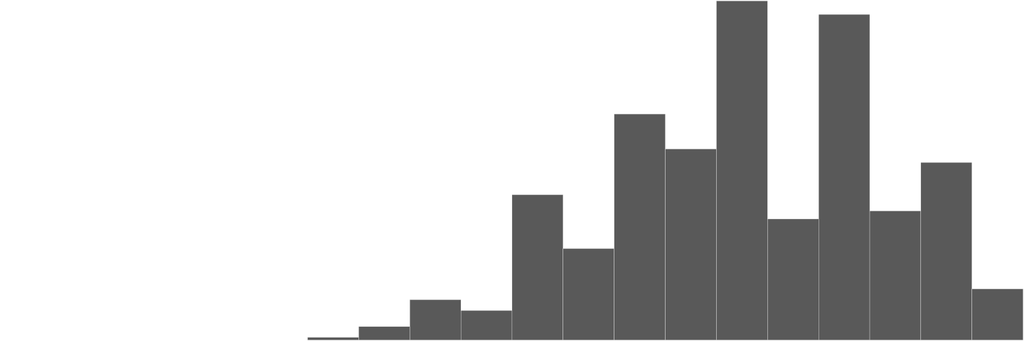

Arousal

3.77

0.76

1.50

5.83

−0.09

−0.12

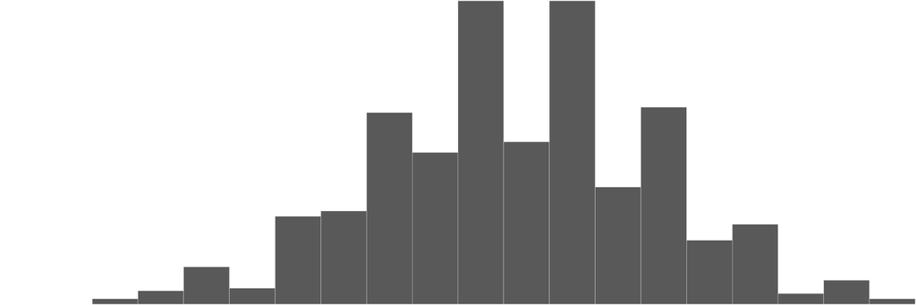

Power

2.73

0.73

1.00

5.17

0.14

−0.26

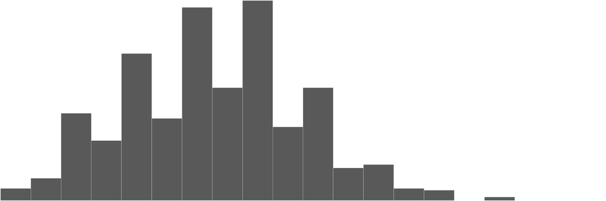

Prestige

3.59

0.74

1.50

5.83

0.04

−0.26

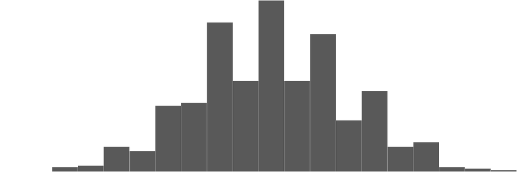

Achievement

4.26

0.72

2.00

6.00

−0.15

−0.17

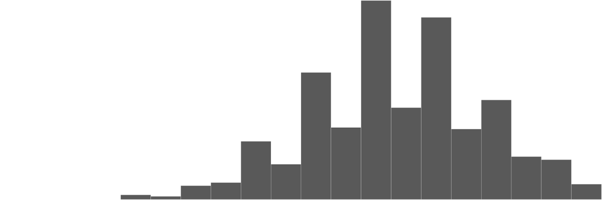

ASC aggression

2.99

0.71

1.00

6.00

0.22

0.80

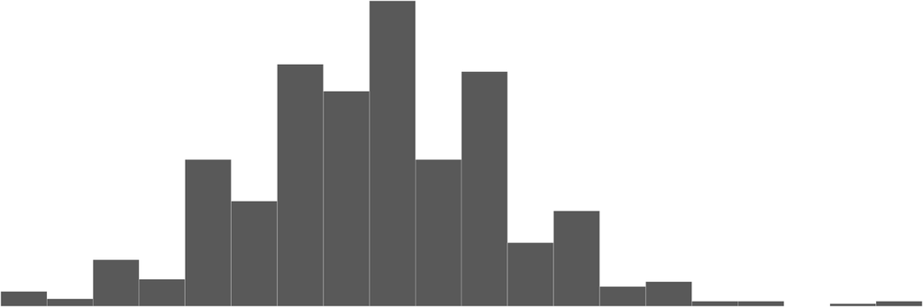

ASC submission

2.91

0.73

1.00

5.17

0.05

−0.21

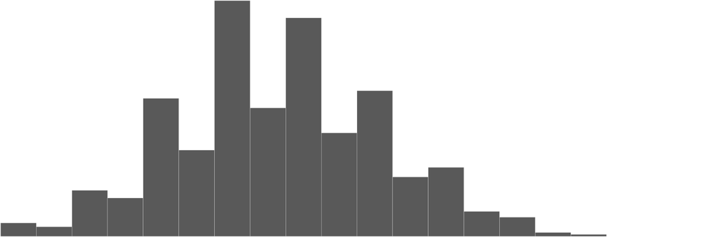

Conventionalism

4.10

0.72

1.71

6.00

−0.15

−0.05

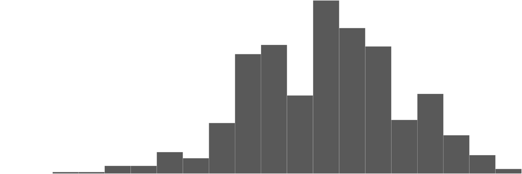

SDO-D

2.53

0.69

1.00

5.12

0.28

−0.23

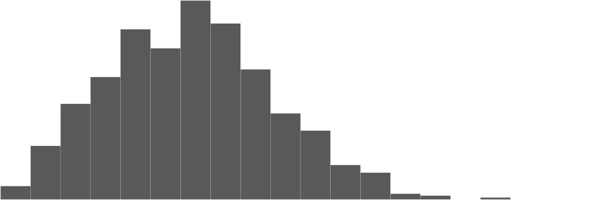

*Note.* Scores are unweighted item means on the 1-to-6 response scale. Histograms use this common horizontal range, with heights scaled within each row.

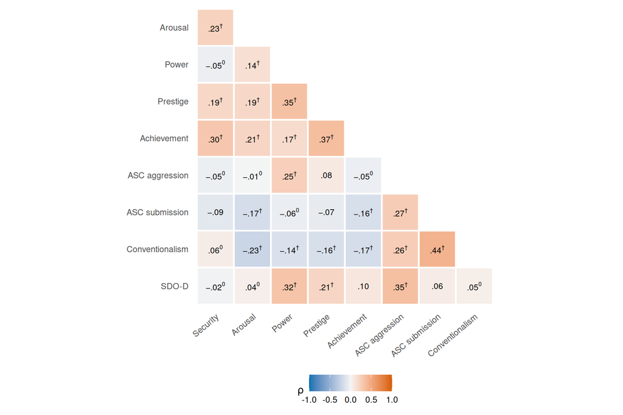

Figure 1: Correlations between the nine scale scores. Superscript † marks evidence for a correlation; superscript zero marks evidence for no correlation.

## 3.4 Bayesian Multiple Regressions (RQ1)

**Research question.** Which motives are associated with each facet of authoritarian orientation, conditional on the other motives and demographics?

**Statistical method.** RQ1 is answered by four separate Bayesian regressions, one per authoritarian-orientation outcome (AP6). Each social-motive predictor’s regression coefficient describes its association with the designated outcome conditional on the other four social-motive predictors, age, gender, and income. Within each regression, the difference between the coefficients of two social-motive predictors is calculated in every posterior draw. The partial correlations of two social-motive predictors, conditional on the other three social-motive predictors, age, gender, and income, are estimated from one joint Bayesian regression of the five social-motive scores on age, gender, and income with correlated residuals; in each posterior draw, the residual correlations are converted into partial correlations, which describe how strongly two motives overlap. (RQ1)

Age and income per household member enter the analyses in bands. Age is grouped into the bands 18–24 and five-year bands from 25–29 to 65–69, each represented by its midpoint. Income per household member is grouped into the bands under 500, 500 to under 630, 630 to under 800, 800 to under 1,050, 1,050 to under 1,400, 1,400 to under 2,000, 2,000 to under 2,800, and 2,800 euro and more, each represented by the geometric mean of its limits, with 357 as the lower limit of the lowest band and 12,500 as the upper limit of the highest. (AP3)

**Evidence measure.** The evidence measure is the adjusted coefficient of each of the five social-motive predictors in each of the four regressions, together with its central 95% credible interval and sign. For two social-motive predictors with opposite predicted signs for the same outcome, it is also the difference between their coefficients, with its credibility and sign. The credible partial correlations of the social-motive predictors qualify the coefficients. (RQ1)

**What decides.** The credible coefficients (AP10), with their signs and estimated sizes, answer RQ1.

A credible difference between two coefficients with opposite predicted signs answers whether the motive predicted positive is more positively associated with the outcome than the motive predicted negative. For a coefficient whose interval includes zero, a credible partial correlation of its motive with another motive indicates that the overlap of the two is possibly responsible for the interval including zero. (RQ1)

For RQ1, Table 4 gives the expected signs of the adjusted associations between the five social motives and the four aspects of authoritarian orientation. (RQ1)

Table 4: Predicted direction of each motive–facet association.

| Motive | ASC aggression | ASC submission | Conventionalism | SDO-D |
| --- | --- | --- | --- | --- |
| Security | + | + | + | + |
| Arousal | − | − | − | − |
| Power | + | − | + | + |
| Prestige | ± | ± | ± | ± |
| Achievement | − | − | − | − |

*Note.* For prestige, ± indicates that either direction is possible; no single direction is predicted.

### 3.4.1 Coefficients

**Synthetic results.** ASC aggression was credibly associated with power (positively) and achievement (negatively). ASC submission was credibly associated with arousal (negatively) and achievement (negatively). Conventionalism was credibly associated with security (positively), arousal (negatively), prestige (negatively) and achievement (negatively). SDO-D was credibly associated with power (positively) and prestige (positively). Figure 2 shows, for each facet, which motives’ coefficients have a central 95% credible interval that excludes zero, and Table 5 gives each coefficient with its uncertainty. The ASC submission model explained the least variance, and the SDO-D model the most (posterior summaries in Table A5).

Of the 15 differences between two motives with opposite predicted signs, seven were credible in the predicted direction. In four of them, at least one of the two coefficients alone was not credible: power exceeded arousal for ASC aggression, conventionalism and SDO-D; power exceeded achievement for SDO-D. Every difference is in Table A6. Of the 10 coefficients whose interval included zero, all belong to a motive with a credible partial correlation with another motive; the largest were power with prestige (.32) and prestige with achievement (.27) (Table A7).

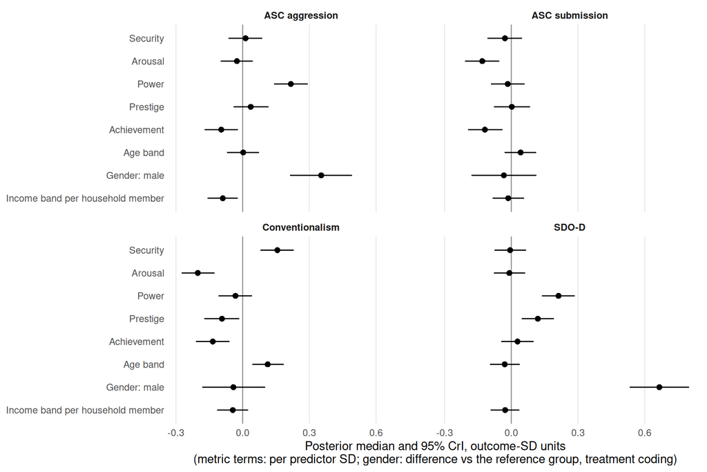

Figure 2: Posterior medians and 95% credible intervals, one panel per outcome.

Table 5: Posterior summary of the Bayesian multiple regressions.

| Outcome | Predictor | Posterior median [95% CrI] |
| --- | --- | --- |
| ASC aggression | Security | 0.01 [−0.06, 0.09] |
|  | Arousal | −0.03 [−0.10, 0.05] |
|  | Power | **0****.22** [0.14, 0.29] |
|  | Prestige | 0.04 [−0.04, 0.12] |
|  | Achievement | **−0****.10** [−0.17, −0.02] |
| ASC submission | Security | −0.03 [−0.11, 0.05] |
|  | Arousal | **−0****.13** [−0.21, −0.05] |
|  | Power | −0.02 [−0.09, 0.06] |
|  | Prestige | 0.00 [−0.08, 0.08] |
|  | Achievement | **−0****.12** [−0.19, −0.04] |
| Conventionalism | Security | **0****.16** [0.08, 0.23] |
|  | Arousal | **−0****.20** [−0.27, −0.13] |
|  | Power | −0.03 [−0.11, 0.04] |
|  | Prestige | **−0****.09** [−0.17, −0.02] |
|  | Achievement | **−0****.13** [−0.21, −0.06] |
| SDO-D | Security | −0.01 [−0.08, 0.07] |
|  | Arousal | −0.01 [−0.08, 0.06] |
|  | Power | **0****.21** [0.14, 0.29] |
|  | Prestige | **0****.12** [0.05, 0.19] |
|  | Achievement | 0.03 [−0.05, 0.10] |

*Note.* Posterior median: the expected difference in the facet, in standard deviations, between two people who differ by one standard deviation in this motive and are alike in the other motives, age, gender and income. 95% CrI: central credible interval. Bold estimate: its interval excludes zero. Every classification is the same under all three priors.

### 3.4.2 Prior-Predictive Checks

In the prior predictive check, between 1.9% and 3.4% of the answers simulated under the primary prior fell outside the response range of 1 to 6, depending on the facet, and at most 6.6% under the permissive prior (for details see Supplement).

### 3.4.3 Prior and Likelihood Sensitivity

#### 3.4.3.1 Prior-Width Comparison

Each regression was fitted with the standard deviation of the slope prior set to 0.10 (skeptical), 0.20 (primary) and 0.40 (permissive). Whether the interval excluded zero was the same for every coefficient under all three priors, so every classification is the same under all of them. For prestige → ASC submission, the posterior median was positive under the primary and permissive priors and negative under the skeptical prior, while zero lay inside its credible interval under every prior. Every coefficient under each of the three priors is reported (for details see Supplement).

#### 3.4.3.2 Local Power Scaling

Making the priors or the data slightly more or less influential (power scaling) flagged no coefficient and no Bayesian R² (for details see Supplement).

#### 3.4.3.3 Posterior-Predictive Checks

In the posterior predictive check, for five features of the scores the observed value lay outside the range of 95% of the data sets simulated from the fitted model: the maximum, excess kurtosis and skewness of ASC aggression (above that range) and the minimum and skewness of SDO-D (above that range) (for details see Supplement).

Only ASC aggression met the preregistered rule for heavier-than-normal tails and was refitted allowing heavier tails, with Student-t errors (for details see Supplement). Of the eight coefficients with a Student-t refit, eight had interpretable comparisons with the Gaussian fit. None changed whether the interval excludes zero, and none changed the sign of its posterior median. The Gaussian model remains primary. The coefficients of both models are compared (for details see Supplement).

### 3.4.4 Validity Gate

The following diagnostics summarise the primary Gaussian fits and their prior-width comparisons. Across the listed fits, maximum R̂ was 1.005, minimum bulk ESS was 5,415, minimum tail ESS was 2,366 and minimum BFMI was 0.92. No fit had a divergent transition or a transition at the maximum tree depth. All 12 listed regression fits, including every prior-sweep fit, passed each diagnostic: bulk and tail ESS, R-hat, divergent transitions, maximum tree depth and BFMI (for details see Supplement). R̂ measures the agreement between the chains, which is complete at a value of one, and the effective sample size (ESS) the number of independent draws the chains are worth. The diagnostics of the refit allowing heavier tails, of the joint model of the five motives and of the joint model of RQ2 are also reported (for details see Supplement). The joint model of the five motives, from which the partial correlations come, passed the validity gate, its residual correlations included.

**NoteValidity gate of this synthetic run**

In this synthetic run, the validity gate required a bulk and tail effective sample size of at least 2,000 for every coefficient, so that the whole pipeline finishes in minutes. The run on the empirical survey data applies the preregistered 10,000 (AP6).

## 3.5 Bayesian Joint Regression (RQ2)

**Statistical method.** RQ2a–RQ2c are answered using one multivariate Bayesian regression of the four authoritarian orientation outcomes on the five social motive predictors, age, gender, and income (AP7). Each motive coefficient is conditional on the other motives and demographics. Residual correlations are conditional on all five motives and demographics, without conditioning on the remaining authoritarian facets (RQ3 conditions on them). The joint posterior provides paired estimates for the comparisons and is also used to derive the motive coefficients for the equal-weight ASC total and its residual correlation with SDO-D. The ASC total is the arithmetic mean of the three raw ASC facet scores. Its residual correlation with SDO-D is derived from the joint residual covariance matrix. Strength differences are calculated within paired posterior draws from the absolute standardised coefficients; the differences for RQ2b are residual minus zero-order correlations. (RQ2)

**Evidence measures and interpretation.** For RQ2a, the evidence measures are the differences in association strength between each pair of authoritarian facets for each social motive. For RQ2b, they are the residual correlations and their differences from the zero-order correlations for the six facet pairs and ASC total–SDO-D. For RQ2c, they are the differences in association strength between each ASC facet and the ASC total.

For RQ2a and RQ2c, a positive difference indicates a stronger association for the first-named outcome, the facet in RQ2c; a negative difference indicates the reverse.

The credible differences and correlations (AP10), with their signs and estimated sizes, answer RQ2a–RQ2c. (RQ2)

**Synthetic results.** The joint model passed the same validity gate as the four separate fits. Its sampling diagnostics are reported beside those of the fits of RQ1 (for details see Supplement).

### 3.5.1 Differences in Motive Associations Across the Facets (RQ2a)

**Research question.** How do each social motive’s associations differ in strength and direction across the four authoritarian facets, conditional on the other motives and demographics?

**Statistical method.** The method quoted in Section 3.5.

**Evidence measures and interpretation.** Those quoted in Section 3.5.

**Synthetic results.** Security was more strongly associated with conventionalism than with ASC aggression and SDO-D. Arousal was more strongly associated with ASC submission than with ASC aggression and SDO-D, and with conventionalism than with ASC aggression and SDO-D. Power was more strongly associated with ASC aggression than with ASC submission and conventionalism, and with SDO-D than with ASC submission and conventionalism. For prestige, all six facet strength differences remained unresolved. Prestige was negatively associated with conventionalism and positively with SDO-D (a sign flip). For achievement, all six facet strength differences remained unresolved.

Table 6 presents all six facet comparisons for each motive. Positive differences indicate a stronger association with the first-named facet; negative differences indicate a stronger association with the second.

Table 6: Paired differences in absolute standardised motive associations across the six authoritarian facet pairs.

| Facet comparison | Security | Arousal | Power | Prestige | Achievement |
| --- | --- | --- | --- | --- | --- |
| ASC aggression − ASC submission | −0.01 [−0.09, 0.07] | **−0****.09** [−0.18, −0.01] | **0****.18** [0.07, 0.27] | 0.01 [−0.06, 0.09] | −0.02 [−0.11, 0.07] |
| ASC aggression − Conventionalism | **−0****.13** [−0.21, −0.04] | **−0****.17** [−0.24, −0.08] | **0****.18** [0.05, 0.27] | −0.05 [−0.15, 0.06] | −0.04 [−0.13, 0.05] |
| ASC aggression − SDO-D | 0.00 [−0.06, 0.07] | 0.00 [−0.06, 0.07] | 0.00 [−0.09, 0.10] | −0.08 [−0.16, 0.01] | 0.06 [−0.05, 0.15] |
| ASC submission − Conventionalism | −0.12 [−0.21, 0.01] | −0.07 [−0.15, 0.01] | −0.01 [−0.08, 0.06] | −0.06 [−0.14, 0.04] | −0.02 [−0.10, 0.07] |
| ASC submission − SDO-D | 0.01 [−0.06, 0.09] | **0****.10** [0.01, 0.19] | **−0****.18** [−0.26, −0.08] | −0.09 [−0.17, 0.01] | 0.08 [−0.03, 0.17] |
| Conventionalism − SDO-D | **0****.13** [0.04, 0.21] | **0****.17** [0.08, 0.25] | **−0****.17** [−0.26, −0.06] | −0.02 [−0.14, 0.09] | 0.10 [−0.01, 0.19] |

*Note.* Posterior median [95% CrI]. Difference in absolute standardised coefficients: first-named outcome minus second-named outcome. Positive values indicate a stronger association with the first outcome; negative values indicate a stronger association with the second. Bold estimate: its interval excludes zero. All available comparisons are shown.

### 3.5.2 Remaining Associations Between the Facets (RQ2b)

**Research question.** How are the four authoritarian facets, and the ASC total and SDO-D, associated before and after conditioning on the social motives and demographics?

**Statistical method.** The method quoted in Section 3.5.

**Evidence measures and interpretation.** Those quoted in Section 3.5.

**Synthetic results.** All seven residual correlations between the authoritarian facets, including the ASC total, were credible: within ASC they ranged from .29 to .42, between the ASC facets and SDO-D from .11 to .26, and between the ASC total and SDO-D it was .22. A residual correlation holds the motives and demographics constant, but not the remaining facets; an edge between an ASC facet and SDO-D in the network (RQ3c) holds the remaining facets and the motives constant, but not the demographics.

Table 7 answers which facet pairs remain correlated once the motives and demographics are held constant, beside each pair’s zero-order correlation implied by the joint model and the difference between the two; the comparison is specified in AP7. The seventh pair is ASC total and SDO-D. A positive difference means more positive, not necessarily stronger; these changes do not establish a causal explanation.

The residual correlation was higher than the zero-order correlation from the joint model, the interval of their difference lying above zero, for ASC aggression – conventionalism; ASC submission – SDO-D; conventionalism – SDO-D. It was lower, the interval lying below zero, for ASC aggression – SDO-D. The interval of their difference included zero for ASC aggression – ASC submission; ASC submission – conventionalism; ASC total – SDO-D.

Table 7: Residual and zero-order (from the joint model) correlations for the six facet pairs and ASC total–SDO-D, with paired signed differences.

| Outcome pair | Zero-order (from the joint model) | Residual | Residual − zero-order |
| --- | --- | --- | --- |
| ASC aggression – ASC submission | **.27** [.20, .33] | **.29** [.22, .35] | .02 [−.00, .05] |
| ASC aggression – Conventionalism | **.26** [.19, .33] | **.31** [.25, .38] | **.05** [.02, .09] |
| ASC aggression – SDO-D | **.35** [.28, .41] | **.26** [.18, .32] | **−****.09** [−.13, −.06] |
| ASC submission – Conventionalism | **.44** [.38, .49] | **.42** [.35, .47] | −.02 [−.04, .00] |
| ASC submission – SDO-D | .06 [−.01, .13] | **.11** [.04, .18] | **.04** [.01, .08] |
| Conventionalism – SDO-D | .05 [−.02, .12] | **.14** [.07, .21] | **.09** [.05, .13] |
| ASC total – SDO-D | **.20** [.14, .27] | **.22** [.15, .29] | .02 [−.02, .06] |

*Note.* Posterior median [95% CrI]. Zero-order correlations from the joint model average over the empirical predictor distribution in the joint-model sample. Differences use paired draws from that model; their signs describe signed correlation change. Bold estimate: its interval excludes zero.

### 3.5.3 ASC Total Versus Its Facets (RQ2c)

**Research question.** How does each social motive’s association with the ASC total differ in strength and direction from its associations with authoritarian aggression, authoritarian submission, and conventionalism?

**Statistical method.** The method quoted in Section 3.5.

**Evidence measures and interpretation.** Those quoted in Section 3.5.

**Synthetic results.** Table 8 compares each facet with the ASC total for each motive. Positive differences indicate a stronger association with the facet; negative differences indicate a stronger association with the total. Signed total coefficients are in Table 9.

Security was more strongly associated with conventionalism than with the ASC total. Arousal was more strongly associated with the ASC total than with ASC aggression. Power was more strongly associated with ASC aggression than with the ASC total. For prestige, all three facet–total strength differences remained unresolved. For achievement, all three facet–total strength differences remained unresolved.

Table 8: Paired differences in absolute standardised motive associations: each ASC facet minus the ASC total.

| Facet comparison | Security | Arousal | Power | Prestige | Achievement |
| --- | --- | --- | --- | --- | --- |
| ASC aggression − ASC total | −0.03 [−0.09, 0.05] | **−0****.13** [−0.19, −0.05] | **0****.14** [0.08, 0.20] | 0.01 [−0.08, 0.09] | −0.06 [−0.12, 0.00] |
| ASC submission − ASC total | −0.03 [−0.11, 0.10] | −0.03 [−0.08, 0.02] | −0.05 [−0.12, 0.08] | −0.01 [−0.07, 0.06] | −0.04 [−0.09, 0.01] |
| Conventionalism − ASC total | **0****.09** [0.04, 0.14] | 0.04 [−0.01, 0.09] | −0.04 [−0.13, 0.09] | 0.06 [−0.03, 0.12] | −0.02 [−0.08, 0.03] |

*Note.* Posterior median [95% CrI]. Difference in absolute standardised coefficients: first-named outcome minus second-named outcome. Positive values indicate a stronger association with the first outcome; negative values indicate a stronger association with the second. Bold estimate: its interval excludes zero. All available comparisons are shown.

Table 9: Supporting signed standardised associations of each motive with the equal-weight ASC total.

| Predictor | Standardised coefficient |
| --- | --- |
| Security | 0.06 [−0.02, 0.13] |
| Arousal | **−0****.16** [−0.23, −0.09] |
| Power | 0.07 [−0.01, 0.15] |
| Prestige | −0.03 [−0.11, 0.05] |
| Achievement | **−0****.15** [−0.23, −0.07] |

*Note.* Posterior median [95% CrI]. Standardised coefficients use ASC-total *SD* per predictor *SD*. Bold estimate: its interval excludes zero.

## 3.6 Bayesian Network Analysis (RQ3)

**Research question.** Which associations between sets remain after conditioning on every other variable in the network?

**Statistical method.** RQ3a–RQ3c are answered together by the preregistered Bayesian Gaussian-copula network (AP8) of the five social motives and four authoritarian facets. No variable is designated as an outcome. The Bayesian network estimates the direct association between two variables conditional on the other seven variables in the network. Demographics are not included in the preregistered network. (RQ3)

**Evidence measures.** The evidence measure is the bagged Bayes factor for each of the 36 possible conditional-dependence edges. (RQ3)

**What decides.** The present bridge edges (AP10), with their signs, answer RQ3a–RQ3c.

An edge classified as absent provides evidence for conditional independence under the fitted model. (RQ3)

### 3.6.1 Associations That Remain Conditional on All Other Scores (RQ3)

**Synthetic results.** Of the 36 possible edges, 11 were classified as present, five absent and 20 inconclusive (Figure 3). An edge is a direct association: the association between two scores that remains when the other seven are held constant; it is not a causal path. Present means evidence for a direct association, absent evidence for none, that is, for conditional independence, and inconclusive that the data do not decide between the two. The tables below organise the main results into three set comparisons: social motives with authoritarian facets (RQ3a), autonomy motives with security and arousal (RQ3b), and ASC facets with SDO-D (RQ3c). Each cell gives the classification, the edge weight of a present edge, and its bagged Bayes factor. The variation across resamples for every edge is shown in Figure A1. Figure 3 shows the full network.

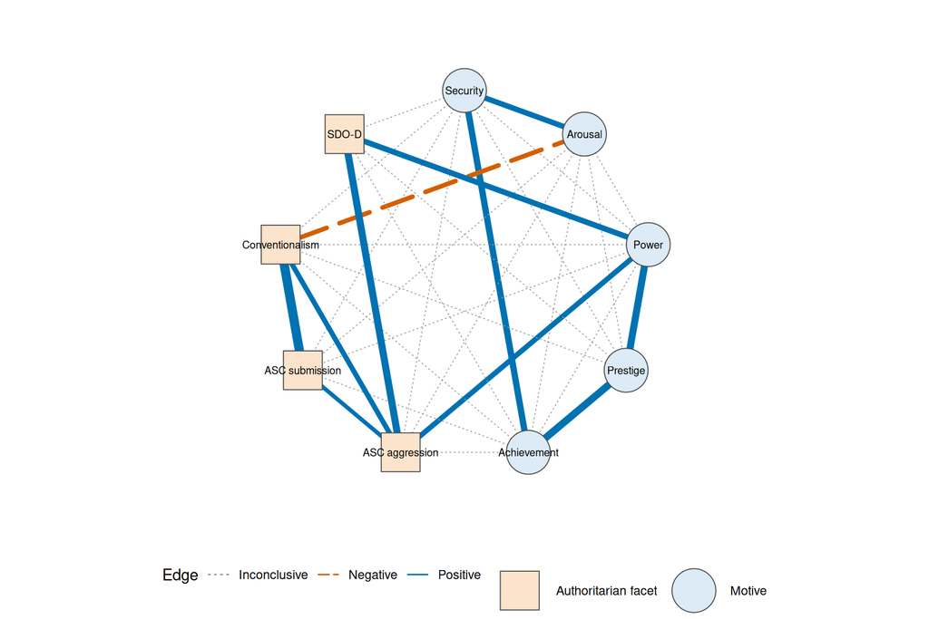

Figure 3: Network of conditional associations among the five social motives and the four authoritarian facets. Edge width illustrates the estimated weight.

### 3.6.2 Associations Between Motives and Facets (RQ3a)

**Research question.** Which associations bridge the social-motive and authoritarian-orientation sets?

**Statistical method.** The method quoted in Section 3.6.

**What decides.** The rule quoted in Section 3.6.

**Synthetic results.** Of the 20 edges between a motive and an authoritarian facet, three were present (arousal – conventionalism, negative; power – ASC aggression, positive; power – SDO-D, positive), three absent (arousal – SDO-D; prestige – ASC aggression; prestige – ASC submission) and 14 inconclusive (Table 10). The present edges are the associations that bridge the motives and the authoritarian facets. Table 10 answers which motive–facet pairs remain associated once all other scores are held constant, and with which sign. Its autonomy rows also show the corresponding RQ1 results for descriptive comparison.

Table 10: Bagged network: classification, edge weight and bagged Bayes factor of every edge between a motive and an authoritarian facet.

| Motive | ASC aggression | ASC submission | Conventionalism | SDO-D |
| --- | --- | --- | --- | --- |
| Security | inconclusive BF<sub>bagged</sub> 0.21 | inconclusive BF<sub>bagged</sub> 1.10 | inconclusive BF<sub>bagged</sub> 7.72 | inconclusive BF<sub>bagged</sub> 0.14 |
| Arousal | inconclusive BF<sub>bagged</sub> 0.11 | inconclusive BF<sub>bagged</sub> 0.32 | **present, −.18** BF<sub>bagged</sub> 24 | absent BF<sub>bagged</sub> 0.08 |
| Power<sup>a</sup> | **present, .20** BF<sub>bagged</sub> > 100 RQ1 + | inconclusive BF<sub>bagged</sub> 0.21 RQ1 unresolved | inconclusive BF<sub>bagged</sub> 6.68 RQ1 unresolved | **present, .22** BF<sub>bagged</sub> > 1,000 RQ1 + |
| Prestige<sup>a</sup> | absent BF<sub>bagged</sub> 0.06 RQ1 unresolved | absent BF<sub>bagged</sub> 0.08 RQ1 unresolved | inconclusive BF<sub>bagged</sub> 0.59 RQ1 − | inconclusive BF<sub>bagged</sub> 1.11 RQ1 + |
| Achievement<sup>a</sup> | inconclusive BF<sub>bagged</sub> 0.23 RQ1 − | inconclusive BF<sub>bagged</sub> 0.71 RQ1 − | inconclusive BF<sub>bagged</sub> 1.15 RQ1 − | inconclusive BF<sub>bagged</sub> 0.27 RQ1 unresolved |

*Note.* Each cell: the classification of the edge in the bagged network, with the signed edge weight (partial correlation) of a present edge in bold, and below it the bagged Bayes factor BF<sub>bagged</sub>. Present at BF<sub>bagged</sub> ≥ 10 (evidence for a direct association), absent at BF<sub>bagged</sub> ≤ 0.10 (evidence for none), inconclusive otherwise. A Bayes factor above 100 is shown as the power of ten it exceeds, one below 0.01 as the power of ten it falls below, at most to the limit that 90,000 sampled networks can resolve (60 resamples of 1,500 sampler steps). With this run’s 60 resamples, Bayes factors above 100 are imprecise: the value shown as > 1,000 for power – SDO-D could lie anywhere from about 800 upward (two standard errors of its bagged inclusion probability, from the spread across the resamples). <sup>a</sup> Autonomy motive: the last line gives its coefficient for that facet in RQ1, credibly positive (+) or negative (−) or unresolved.

The autonomy–facet results are also read alongside their adjusted associations in RQ1. This comparison is descriptive rather than a separate research question.

Of the 12 edges between power, prestige and achievement and the four facets, two were present (power – ASC aggression; power – SDO-D), two absent (prestige – ASC aggression; prestige – ASC submission) and eight inconclusive. Of the seven pairs of an autonomy motive and a facet credibly associated in the RQ1 regressions, two share a present edge (power – ASC aggression; power – SDO-D) and five share an inconclusive edge (prestige – conventionalism; prestige – SDO-D; achievement – ASC aggression; achievement – ASC submission; achievement – conventionalism). A motive credibly associated with a facet in RQ1 whose edge with that facet is classified as absent in the network is read as screened off by the remaining network variables, that is, as conditionally independent of that facet given them, and not as a contradiction between the analyses (AP10); no motive–facet pair is read this way. This reading beside RQ1 is descriptive: besides conditioning on the other authoritarian facets, the network leaves out age, gender and income, measures each association as a partial correlation of rank-based normal scores rather than as a regression coefficient, and analyses 700 cases against the regressions’ 699, so a difference cannot be attributed to the other facets alone.

### 3.6.3 Autonomy Motives With the Security and Arousal Motives (RQ3b)

**Research question.** Are power, prestige, and achievement positively associated with the arousal motive and negatively associated with the security motive, when the remaining network variables are held constant?

**Statistical method.** The method quoted in Section 3.6.

**What decides.** The rule quoted in Section 3.6.

**Synthetic results.** Of the six edges of power, prestige and achievement with security and arousal, one was present (security – achievement), none absent and five inconclusive; power shares an inconclusive edge with both; prestige shares an inconclusive edge with both; achievement shares a present edge with security and an inconclusive edge with arousal.

The present edge between achievement and security was positive (edge weight .25), the opposite of the negative association with security that RQ3b asks about. No edge of power, prestige and achievement with arousal was present. Table 11 shows these six comparisons conditional on all other scores.

Table 11: Bagged network: classification, edge weight and bagged Bayes factor of autonomy motives with security and arousal.

| Autonomy motive | Security | Arousal |
| --- | --- | --- |
| Power | inconclusive BF<sub>bagged</sub> 1.57 | inconclusive BF<sub>bagged</sub> 1.23 |
| Prestige | inconclusive BF<sub>bagged</sub> 1.44 | inconclusive BF<sub>bagged</sub> 0.74 |
| Achievement | **present, .25** BF<sub>bagged</sub> > 10,000 | inconclusive BF<sub>bagged</sub> 0.51 |

*Note.* Each cell: the classification of the edge in the bagged network, with the signed edge weight (partial correlation) of a present edge in bold, and below it the bagged Bayes factor BF<sub>bagged</sub>. Present at BF<sub>bagged</sub> ≥ 10 (evidence for a direct association), absent at BF<sub>bagged</sub> ≤ 0.10 (evidence for none), inconclusive otherwise. A Bayes factor above 100 is shown as the power of ten it exceeds, one below 0.01 as the power of ten it falls below, at most to the limit that 90,000 sampled networks can resolve (60 resamples of 1,500 sampler steps). The edge shown as > 10,000 was in every network sampled in all 60 resamples (90,000 in all), so its Bayes factor lies beyond what this run can resolve.

### 3.6.4 ASC Facets With SDO-D (RQ3c)

**Research question.** Which ASC facets remain associated with SDO-D, conditional on the remaining facets and social motives?

**Statistical method.** The method quoted in Section 3.6.

**What decides.** The rule quoted in Section 3.6.

**Synthetic results.** These edges are conditional on the other two ASC facets and on the motives, but not on the demographics; the residual correlations of RQ2b are conditional on the motives and the demographics, but not on the other two ASC facets.

Of the three edges between an ASC facet and SDO-D, one was present (ASC aggression – SDO-D, positive), two absent (ASC submission – SDO-D; conventionalism – SDO-D) and none inconclusive (Table 12). Conventionalism – SDO-D and ASC submission – SDO-D have residual correlations whose intervals lie above zero in RQ2b but absent edges here; because the two analyses hold different variables constant, these results do not contradict each other. Table 12 shows which ASC facets remain associated with SDO-D once all other scores are held constant.

Table 12: Bagged network: classification, edge weight and bagged Bayes factor of ASC facets with SDO-D.

| ASC facet | SDO-D |
| --- | --- |
| ASC aggression | **present, .28** BF<sub>bagged</sub> > 10,000 |
| ASC submission | absent BF<sub>bagged</sub> 0.06 |
| Conventionalism | absent BF<sub>bagged</sub> 0.07 |

*Note.* Each cell: the classification of the edge in the bagged network, with the signed edge weight (partial correlation) of a present edge in bold, and below it the bagged Bayes factor BF<sub>bagged</sub>. Present at BF<sub>bagged</sub> ≥ 10 (evidence for a direct association), absent at BF<sub>bagged</sub> ≤ 0.10 (evidence for none), inconclusive otherwise. A Bayes factor above 100 is shown as the power of ten it exceeds, one below 0.01 as the power of ten it falls below, at most to the limit that 90,000 sampled networks can resolve (60 resamples of 1,500 sampler steps). The edge shown as > 10,000 was in every network sampled in all 60 resamples (90,000 in all), so its Bayes factor lies beyond what this run can resolve.

### 3.6.5 Stability

#### 3.6.5.1 Resample Fits

60 of 60 network resample fits succeeded (100.0%); 1,500 sweeps per fit were retained after burn-in.

#### 3.6.5.2 Comparison With the Full-Data Network

The bagged network is the preregistered answer. The network fitted once to the whole sample, the full-data network, shows which edge decisions depend on this particular sample: an edge whose classification differs between the two has evidence that depends on which respondents happen to be in the sample. The comparison is descriptive and changes no classification. The bagged and full-data decisions agreed for 22 of 36 edges, and every disagreement became inconclusive after bagging. Every conclusive bagged decision crossed its matching threshold in most resamples (for details see Supplement).

#### 3.6.5.3 Edge-Prior Sensitivity

The full-data network was also refitted with the prior inclusion probability of every edge set to .25, .50, .75 in turn; the classification of 9 edges depends on it: security – ASC aggression; security – ASC submission; arousal – prestige; arousal – SDO-D; power – achievement; prestige – ASC submission; prestige – conventionalism; achievement – ASC submission; achievement – conventionalism (for details see Supplement). This comparison concerns the full-data fits, not the bagged network, whose preregistered classifications use .50.

## 3.7 Dimensionality and Item Correspondence (SRQ1)

**Research question.** How distinctly are the five social motives and the four facets of authoritarian orientation represented when their complete item sets are examined together?

**Statistical method.** The exploratory factor analyses focus on the two complete item sets for the social motives and for authoritarian orientation.

The exploratory solutions are examined as specified in AP9.

The five-factor confirmatory model of the social motives and the four-factor model of the ASC facets together with SDO-D, specified in AP4, provide complementary evidence through their fit, loadings, and latent factor correlations. (SRQ1)

**Evidence measures.** The evidence measures for the number of dimensions are the factor numbers suggested by the nine criteria (AP9). The evidence measures for the correspondence with the intended constructs are, for every examined solution, the adjusted Rand index, expected-pair retention, empirical-pair purity, and the cross-loading and weak-loading counts (AP9). The evidence measures of the five-factor motive model and the four-factor model of ASC and SDO-D (AP4) are their fit indices: the scaled χ², the robust CFI, TLI and RMSEA with its 90% interval, and the SRMR. (SRQ1)

**What decides.** The suggested numbers of factors indicate whether the data suggest five motive dimensions and four authoritarian dimensions, or a different number.

The item groupings show how well the factors distinguish the intended motives and authoritarian facets. Items from different constructs can group on the same factor (merging), while items from one construct can form separate groups (splitting). For example, a five-factor solution could combine power and prestige while dividing arousal into two groups. It would then have the expected number of factors without reproducing the intended structure.

The adjusted Rand index summarises how closely the estimated item groups match the intended scales. Expected-pair retention captures splitting. Empirical-pair purity captures merging. Cross-loading is examined separately, because an item can remain in its intended group while relating strongly to another factor. (SRQ1)

### 3.7.1 Number of Factors

**Synthetic results.** All nine criteria suggested the expected number of factors for every single scale and the item sets doPL-6 (dominance and prestige) and UMS-6 (intimacy and achievement). The criteria disagreed in three cases: for ASC, seven of nine criteria suggested the expected number and two fewer; for all social motive scales, eight of nine criteria suggested the expected number and one fewer; for ASC and SDO-D, six of nine criteria suggested the expected number and three fewer. Table A8 gives the number each criterion suggested for the scales and item sets on which they disagreed.

### 3.7.2 Item Correspondence and Loading Clarity

Expected-pair retention below one indicates that a scale was split, and empirical-pair purity below one that scales were merged. In the expected solution of each of the five item sets, the adjusted Rand index, expected-pair retention and empirical-pair purity were all 1.00: every factor held the items of exactly one scale (details in Section A4).

All five lower-factor solutions merged whole scales without splitting their items. Table A9 answers, for every solution whose item grouping differs from the intended scales, how closely the estimated factors match them.

An item loads weakly when none of its absolute loadings reaches .40, and it cross-loads when two or more do. In the one-factor solution of each of the nine scales analysed on its own, no item loaded weakly; with one factor, no item can cross-load. ASC, three factors (expected): no item loaded weakly; one item cross-loaded: conventionalism item 3, with a second loading of .44 on the factor of ASC submission. ASC, one factor: 4 of the 19 items loaded weakly, all of them ASC aggression items. ASC, two factors: ASC submission and conventionalism shared a factor; no item loaded weakly or cross-loaded; the largest second loading was .12 (ASC submission item 3, on the factor of ASC aggression). DoPL-6 (dominance and prestige), two factors (expected): no item loaded weakly or cross-loaded; the largest second loading was .10 (prestige item 2, on the factor of power). UMS-6 (intimacy and achievement), two factors (expected): no item loaded weakly or cross-loaded; the largest second loading was .07 (security item 2, on the factor of achievement). All social motive scales, five factors (expected): no item loaded weakly or cross-loaded; the largest second loading was .12 (power item 2, on the factor of arousal). All social motive scales, one factor: 16 of the 30 items loaded weakly: 6 security, 4 arousal and 6 power items. ASC and SDO-D, four factors (expected): no item loaded weakly; one item cross-loaded: conventionalism item 3, with a second loading of .44 on the factor of ASC submission. ASC and SDO-D, two factors: ASC aggression and SDO-D shared a factor, as did ASC submission and conventionalism; 5 of the 27 items loaded weakly, all of them ASC aggression items; none cross-loaded; the largest second loading was .31 (ASC aggression item 2, on the factor of ASC submission and conventionalism). ASC and SDO-D, three factors: ASC submission and conventionalism shared a factor; no item loaded weakly or cross-loaded; the largest second loading was .17 (ASC submission item 6, on the factor of ASC aggression). Table A10 and Table A11 give every item’s loadings in the expected solutions and name, for a cross-loading item, the scales of the factor it also loads on.

### 3.7.3 Confirmatory Models of the Combined Item Sets

Beside the exploratory analyses, the preregistration fits confirmatory models of the two largest item sets: all five social motives, with five factors, and SDO-D with the three ASC scales, with four factors. Both confirmatory models of these item sets converged and were admissible. Among these models, minimum CFI = .971, minimum TLI = 0.968, maximum RMSEA = .027 and maximum SRMR = .037 (for details see Supplement). The latent correlations between their factors are in Table A3 and Table A4.

## 3.8 Deviations From the Preregistration

Any deviation from the preregistered analysis is listed here (Table 13), with the date it was made and the reason.

Table 13: Deviations from the preregistration.

| Date | Preregistered | Deviation | Reason |
| --- | --- | --- | --- |
| — | — | None to date | — |

# 4 Discussion

This run computed every statistical measure the preregistration names for the research questions: every regression fit of RQ1 and RQ2, the refit allowing heavier tails and all network resamples passed the validity gate. The problems planted in the synthetic preregistration data exercised every exclusion criterion, the rule for gender-diverse responses below the minimum of 30, the fill of nine missing values, the omission of a case without gender from the regressions, the refit allowing heavier tails for ASC aggression and the count of one item with a second loading of .40 or more (a cross-loading): conventionalism item 3, on the factor of ASC submission.

The social-neophilia scale is an unpublished scale developed for this study; no separate psychometric validation was conducted before the survey (preregistration, M13). This report describes its reliability and factor structure, which does not validate it.

# References

Zehetleitner, M., Castiglione, C., Drastik, J., Matterstock, D., & Prell, N. (2026). *Motives and ideology: Bischof’s Zürich model of social motivation, right-wing authoritarianism and social dominance orientation* [Preregistration]. PsychArchives. https://doi.org/10.23668/psycharchives.22601

# Appendix

The appendix follows the order of the Results; each section names the questions its tables and figures answer. It holds the results about the constructs, the estimates a reader uses to interpret an answer: how the items relate to their scales, and how the scales, the motives and the facets relate to each other. The statistical checks of these results, the fit of the models and the sampling, their dependence on the choices of the analysis, and the detail of the data handling, are in the electronic supplement. Data files that accompany the analysis code hold the complete numbers behind the tables of both parts.

## A1 Measurement

**Question.** How strongly does each item reflect its scale, and how strongly are the scales related once measurement error is taken into account?

Table A1 and Table A2 answer how strongly each item reflects its scale in every confirmatory model that holds it: the one-factor model of its scale and the multi-factor models of its item sets.

| Scale | Item | One-factor model of the scale | UMS-6 (intimacy and achievement) / DoPL-6 (dominance and prestige) | Five social-motive factors |
| --- | --- | --- | --- | --- |
| Security | UMS_int_1 | .66 | .67 | .64 |
|  | UMS_int_2 | .62 | .59 | .58 |
|  | UMS_int_3 | .64 | .65 | .65 |
|  | UMS_int_4 | .60 | .60 | .60 |
|  | UMS_int_5 | .63 | .63 | .66 |
|  | UMS_int_6 | .61 | .61 | .63 |
| Achievement | UMS_ach_1 | .58 | .57 | .56 |
|  | UMS_ach_2 | .65 | .63 | .65 |
|  | UMS_ach_3 | .63 | .63 | .62 |
|  | UMS_ach_4 | .65 | .66 | .65 |
|  | UMS_ach_5 | .64 | .66 | .66 |
|  | UMS_ach_6 | .65 | .65 | .67 |
| Power | DOPL_dom_1 | .63 | .63 | .64 |
|  | DOPL_dom_2 | .67 | .68 | .67 |
|  | DOPL_dom_3 | .66 | .65 | .64 |
|  | DOPL_dom_4 | .67 | .65 | .66 |
|  | DOPL_dom_5 | .62 | .64 | .64 |
|  | DOPL_dom_6 | .67 | .67 | .67 |
| Prestige | DOPL_pre_1 | .65 | .63 | .63 |
|  | DOPL_pre_2 | .59 | .63 | .63 |
|  | DOPL_pre_3 | .66 | .67 | .67 |
|  | DOPL_pre_4 | .64 | .65 | .64 |
|  | DOPL_pre_5 | .67 | .65 | .65 |
|  | DOPL_pre_6 | .68 | .67 | .68 |
| Arousal | UNT_1_r | .70 | — | .72 |
|  | UNT_2 | .66 | — | .68 |
|  | UNT_3 | .73 | — | .70 |
|  | UNT_4_r | .65 | — | .66 |
|  | UNT_5 | .62 | — | .62 |
|  | UNT_6 | .63 | — | .60 |

*Note.* Completely standardised loadings. An em dash marks a scale that the model of that column does not hold. The unstandardised loadings and the standard errors of both metrics are in cfa_loadings.csv.

Table A1: Standardised loadings of the motive items in every confirmatory model that holds them.

| Scale | Item | One-factor model of the scale | ASC three-factor model | Three ASC factors and SDO-D |
| --- | --- | --- | --- | --- |
| ASC aggression | ASC_aag_1 | .63 | .61 | .61 |
|  | ASC_aag_2 | .65 | .67 | .64 |
|  | ASC_aag_3_r | .63 | .66 | .65 |
|  | ASC_aag_4_r | .66 | .65 | .67 |
|  | ASC_aag_5_r | .63 | .63 | .64 |
|  | ASC_aag_6 | .61 | .60 | .60 |
| ASC submission | ASC_asu_1 | .65 | .65 | .65 |
|  | ASC_asu_2 | .66 | .66 | .66 |
|  | ASC_asu_3_r | .58 | .62 | .62 |
|  | ASC_asu_4 | .64 | .64 | .64 |
|  | ASC_asu_5_r | .64 | .62 | .62 |
|  | ASC_asu_6_r | .65 | .64 | .64 |
| Conventionalism | ASC_con_1_r | .63 | .62 | .62 |
|  | ASC_con_2 | .61 | .57 | .57 |
|  | ASC_con_3 | .71 | .86 | .86 |
|  | ASC_con_4 | .61 | .58 | .58 |
|  | ASC_con_5_r | .67 | .62 | .62 |
|  | ASC_con_6_r | .62 | .59 | .59 |
|  | ASC_con_7 | .66 | .62 | .62 |
| SDO-D | SDO_D_1 | .63 | — | .64 |
|  | SDO_D_2 | .64 | — | .64 |
|  | SDO_D_3 | .67 | — | .67 |
|  | SDO_D_4 | .66 | — | .64 |
|  | SDO_D_5_r | .66 | — | .65 |
|  | SDO_D_6_r | .63 | — | .65 |
|  | SDO_D_7_r | .61 | — | .61 |
|  | SDO_D_8_r | .67 | — | .69 |

*Note.* Completely standardised loadings. An em dash marks a scale that the model of that column does not hold. The unstandardised loadings and the standard errors of both metrics are in cfa_loadings.csv.

Table A2: Standardised loadings of the items of authoritarian orientation in every confirmatory model that holds them.

Table A3 and Table A4 answer how strongly the scales are related once measurement error is taken into account: the latent correlations of the confirmatory models that hold several scales. The smaller models “UMS-6 (intimacy and achievement)”, “DoPL-6 (dominance and prestige)” and “ASC three-factor model” give the same latent correlations for the pairs they share, to two decimals.

| Motive | Security | Arousal | Power | Prestige |
| --- | --- | --- | --- | --- |
| Arousal | .30 (.04) |  |  |  |
| Power | −.06 (.05) | .19 (.05) |  |  |
| Prestige | .25 (.05) | .24 (.05) | .44 (.04) |  |
| Achievement | .40 (.04) | .27 (.04) | .22 (.05) | .47 (.04) |

*Note.* Latent correlation (standard error) from the confirmatory model “Five social-motive factors”.

Table A3: Latent correlations between the five social motives.

| Authoritarian facet | ASC aggression | ASC submission | Conventionalism |
| --- | --- | --- | --- |
| ASC submission | .35 (.04) |  |  |
| Conventionalism | .34 (.04) | .59 (.03) |  |
| SDO-D | .45 (.04) | .08 (.05) | .06 (.05) |

*Note.* Latent correlation (standard error) from the confirmatory model “Three ASC factors and SDO-D”.

Table A4: Latent correlations between the four facets of authoritarian orientation.

## A2 Bayesian Multiple Regressions (RQ1)

**Research question.** Which motives are associated with each facet of authoritarian orientation, conditional on the other motives and demographics?

Table A5 answers how much of the variance of each facet the five motives, age, gender and income explain together, in the four regressions with the preregistered prior.

| Outcome | Bayesian R² [95% CrI] |
| --- | --- |
| ASC aggression | .12 [.08, .16] |
| ASC submission | .05 [.03, .09] |
| Conventionalism | .12 [.08, .16] |
| SDO-D | .23 [.18, .28] |

*Note.* Posterior median [95% CrI] of the model-based Bayesian R²: var(mu) / (var(mu) + sigma^2).

Table A5: Explained variance of each facet in the regressions with the preregistered prior.

Table A6 answers, for each pair of motives with opposite predicted signs, whether the coefficient of the motive predicted positive exceeded that of the motive predicted negative.

| Facet | Motive predicted positive minus motive predicted negative | Difference [95% CrI] |
| --- | --- | --- |
| ASC aggression | Security minus arousal | 0.04 [−0.08, 0.15] |
|  | Power minus arousal | **0****.24** [0.13, 0.35] |
|  | Security minus achievement | 0.11 [−0.01, 0.23] |
|  | Power minus achievement | **0****.31** [0.20, 0.43] |
| ASC submission | Security minus arousal | 0.10 [−0.02, 0.22] |
|  | Security minus power | −0.01 [−0.12, 0.09] |
|  | Security minus achievement | 0.09 [−0.03, 0.21] |
| Conventionalism | Security minus arousal | **0****.36** [0.24, 0.47] |
|  | Power minus arousal | **0****.17** [0.06, 0.28] |
|  | Security minus achievement | **0****.29** [0.17, 0.41] |
|  | Power minus achievement | 0.10 [−0.01, 0.21] |
| SDO-D | Security minus arousal | 0.00 [−0.11, 0.11] |
|  | Power minus arousal | **0****.22** [0.11, 0.33] |
|  | Security minus achievement | −0.03 [−0.15, 0.08] |
|  | Power minus achievement | **0****.18** [0.08, 0.29] |

*Note.* Posterior median of the difference between the two standardised coefficients in the same regression, formed in every posterior draw, with its central 95% credible interval. Bold estimate: its interval excludes zero.

Table A6: Differences between the coefficients of two motives with opposite predicted signs.

Table A7 answers how strongly two motives overlap once the other three motives, age, gender and income are held constant.

| Motives | Partial correlation [95% CrI] |
| --- | --- |
| Security and arousal | **.18** [.11, .25] |
| Security and power | **−****.14** [−.22, −.07] |
| Security and prestige | **.12** [.04, .19] |
| Security and achievement | **.24** [.17, .30] |
| Arousal and power | **.09** [.02, .17] |
| Arousal and prestige | **.08** [.00, .15] |
| Arousal and achievement | **.10** [.02, .17] |
| Power and prestige | **.32** [.25, .38] |
| Power and achievement | **.08** [.00, .15] |
| Prestige and achievement | **.27** [.20, .34] |

*Note.* Posterior median of the partial correlation, conditional on the other three motives, age, gender and income, from the joint model of the five motive scores, with its central 95% credible interval. Bold estimate: its interval excludes zero.

Table A7: Partial correlations of the five motives.

## A3 Bayesian Network Analysis (RQ3)

**Research question.** Which associations between sets remain after conditioning on every other variable in the network?

Figure A1 answers how much each edge’s inclusion probability varies across the bootstrap resamples and where the full-data network falls, and Figure A2 how the full-data network differs from the preregistered bagged network. The full-data network is the network fitted once to the whole sample.

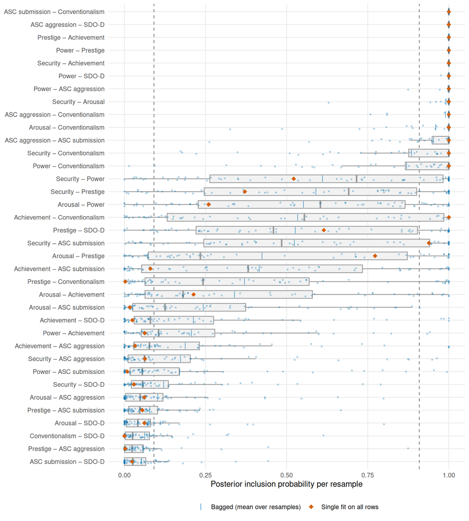

Figure A1: Inclusion probability of every edge across the bootstrap resamples, with the value of the full-data network marked.

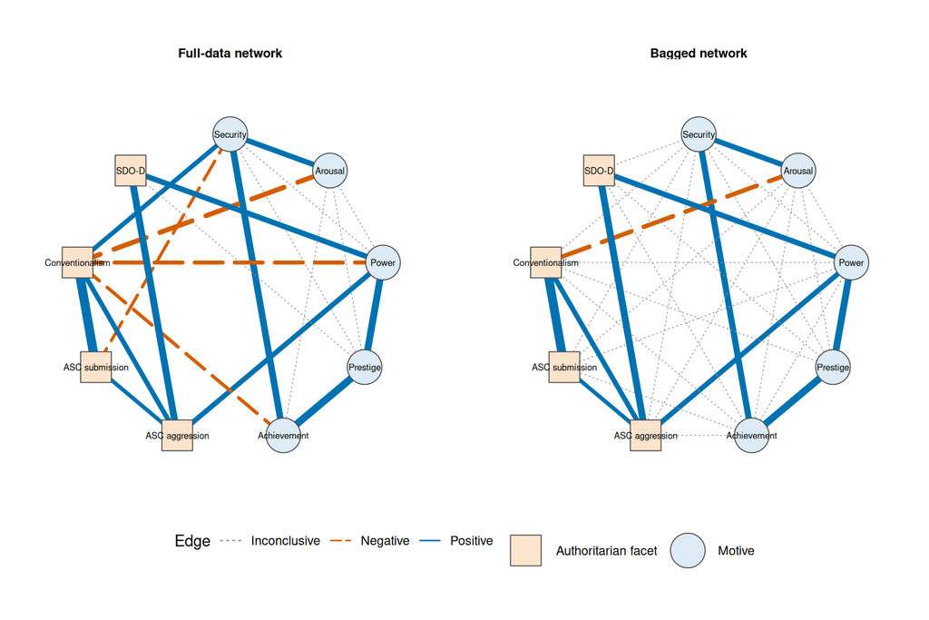

Figure A2: The full-data network and the bagged network side by side, drawn as the network of the Results.

## A4 Exploratory Factor Analyses (SRQ1)

**Research question.** How distinctly are the five social motives and the four facets of authoritarian orientation represented when their complete item sets are examined together?

All nine criteria suggested the expected number of factors for the nine scales analysed on their own and the item sets DoPL-6 (dominance and prestige) and UMS-6 (intimacy and achievement). Table A8 gives the number each criterion suggested for the three scales or item sets on which they disagreed.

| Scale or item set | Items | Expected | Parallel analysis (principal components) | Parallel analysis (common factors) | Comparison data | Velicer’s minimum average partial | Kaiser criterion | Empirical Kaiser criterion | Optimal coordinates | Acceleration factor | Very simple structure (complexity one) |
| --- | --- | --- | --- | --- | --- | --- | --- | --- | --- | --- | --- |
| ASC | 19 | 3 | 3 | 3 | 3 | 3 | 3 | 3 | 3 | 1 | 2 |
| All social motive scales | 30 | 5 | 5 | 5 | 5 | 5 | 5 | 5 | 5 | 1 | 5 |
| ASC and SDO-D | 27 | 4 | 4 | 4 | 4 | 4 | 4 | 4 | 2 | 2 | 3 |

*Note.* Expected: number of factors in the intended scale structure, one per scale.

Table A8: Number of factors each criterion suggests, for the scales and item sets on which the criteria disagree.

In the expected solution of each of the five item sets, every factor held the items of exactly one scale (adjusted Rand index, expected-pair retention and empirical-pair purity all 1.00). Table A9 gives the five solutions whose grouping differed; none of them split a scale (expected-pair retention 1.00) and no item cross-loaded in them.

| Item set | Solution | Adjusted Rand index | Empirical-pair purity | Scales sharing a factor | Weakly loading items |
| --- | --- | --- | --- | --- | --- |
| ASC | 1 factor (suggested by 1 of 9 criteria) | .00 | .30 | ASC aggression, ASC submission and conventionalism | 4 of 19 |
|  | 2 factors (suggested by 1 of 9 criteria) | .53 | .55 | ASC submission and conventionalism | 0 of 19 |
| All social motive scales | 1 factor (suggested by 1 of 9 criteria) | .00 | .17 | Security, arousal, power, prestige and achievement | 16 of 30 |
| ASC and SDO-D | 2 factors (suggested by 2 of 9 criteria) | .48 | .47 | ASC aggression and SDO-D; ASC submission and conventionalism | 5 of 27 |
|  | 3 factors (suggested by 1 of 9 criteria) | .71 | .65 | ASC submission and conventionalism | 0 of 27 |

*Note.* Adjusted Rand index: agreement of the estimated grouping of the items with the intended scales (1: identical, 0: chance level). Expected-pair retention: share of the item pairs of one scale that share a factor; below 1, a scale was split. Empirical-pair purity: share of the item pairs on one factor that belong to one scale; below 1, scales were merged. Weakly loading: no absolute loading of at least .40. Cross-loading: two or more absolute loadings of at least .40.

Table A9: Correspondence between the intended scales and the estimated factors, for the solutions whose item grouping differs from the scales.

In the one-factor solution of each of the nine scales analysed on its own, every item loaded at least .40; with one factor, no item can cross-load.

Table A10 and Table A11 answer, item by item, how strongly each item loads on the factor of its own scale in the expected solutions, with one factor per scale, and which items load on a second factor as well or on none clearly.

| Scale | Item | DoPL-6 or UMS-6, 2 factors: largest loading | DoPL-6 or UMS-6, 2 factors: next-largest loading | All social motive scales, 5 factors: largest loading | All social motive scales, 5 factors: next-largest loading |
| --- | --- | --- | --- | --- | --- |
| Security | UMS_int_1 | .64 | .02 | .64 | .07 |
|  | UMS_int_2 | .64 | .07 | .65 | .05 |
|  | UMS_int_3 | .62 | .05 | .61 | .06 |
|  | UMS_int_4 | .59 | .01 | .58 | .02 |
|  | UMS_int_5 | .63 | .01 | .61 | .06 |
|  | UMS_int_6 | .62 | .01 | .60 | .07 |
| Arousal | UNT_1_r | — | — | .67 | .06 |
|  | UNT_2 | — | — | .65 | .05 |
|  | UNT_3 | — | — | .75 | .07 |
|  | UNT_4_r | — | — | .62 | .08 |
|  | UNT_5 | — | — | .61 | .05 |
|  | UNT_6 | — | — | .65 | .04 |
| Power | DOPL_dom_1 | .64 | .01 | .62 | .08 |
|  | DOPL_dom_2 | .65 | .04 | .67 | .12 |
|  | DOPL_dom_3 | .68 | .04 | .67 | .04 |
|  | DOPL_dom_4 | .67 | .02 | .67 | .06 |
|  | DOPL_dom_5 | .59 | .07 | .58 | .09 |
|  | DOPL_dom_6 | .67 | .00 | .67 | .02 |
| Prestige | DOPL_pre_1 | .66 | .03 | .67 | .06 |
|  | DOPL_pre_2 | .56 | .10 | .52 | .12 |
|  | DOPL_pre_3 | .66 | .02 | .65 | .03 |
|  | DOPL_pre_4 | .62 | .04 | .61 | .05 |
|  | DOPL_pre_5 | .69 | .04 | .67 | .06 |
|  | DOPL_pre_6 | .69 | .02 | .68 | .04 |
| Achievement | UMS_ach_1 | .60 | .05 | .60 | .04 |
|  | UMS_ach_2 | .66 | .04 | .64 | .05 |
|  | UMS_ach_3 | .63 | .00 | .63 | .03 |
|  | UMS_ach_4 | .64 | .03 | .64 | .05 |
|  | UMS_ach_5 | .62 | .05 | .62 | .07 |
|  | UMS_ach_6 | .64 | .02 | .61 | .09 |

*Note.* Absolute pattern loadings in the expected solution of each item set, one factor per scale. Every item had its largest loading on the factor of its own scale. An em dash marks an item outside that item set.

Table A10: Item membership of the motive items in the expected solutions of their item sets.

| Scale | Item | ASC, 3 factors: largest loading | ASC, 3 factors: next-largest loading | ASC and SDO-D, 4 factors: largest loading | ASC and SDO-D, 4 factors: next-largest loading |
| --- | --- | --- | --- | --- | --- |
| ASC aggression | ASC_aag_1 | .61 | .03 | .62 | .02 |
|  | ASC_aag_2 | .63 | .04 | .67 | .07 |
|  | ASC_aag_3_r | .62 | .08 | .61 | .09 |
|  | ASC_aag_4_r | .67 | .05 | .64 | .06 |
|  | ASC_aag_5_r | .63 | .03 | .61 | .04 |
|  | ASC_aag_6 | .62 | .01 | .60 | .03 |
| ASC submission | ASC_asu_1 | .66 | .03 | .66 | .03 |
|  | ASC_asu_2 | .65 | .03 | .65 | .02 |
|  | ASC_asu_3_r | .54 | .10 | .54 | .09 |
|  | ASC_asu_4 | .64 | .01 | .64 | .01 |
|  | ASC_asu_5_r | .64 | .05 | .64 | .05 |
|  | ASC_asu_6_r | .67 | .08 | .67 | .07 |
| Conventionalism | ASC_con_1_r | .61 | .07 | .61 | .08 |
|  | ASC_con_2 | .61 | .03 | .60 | .03 |
|  | ASC_con_3 | .50<sup>a</sup> | .44 | .50<sup>a</sup> | .44 |
|  | ASC_con_4 | .62 | .03 | .61 | .04 |
|  | ASC_con_5_r | .68 | .03 | .68 | .03 |
|  | ASC_con_6_r | .63 | .03 | .63 | .03 |
|  | ASC_con_7 | .66 | .00 | .66 | .05 |
| SDO-D | SDO_D_1 | — | — | .62 | .04 |
|  | SDO_D_2 | — | — | .65 | .06 |
|  | SDO_D_3 | — | — | .66 | .07 |
|  | SDO_D_4 | — | — | .67 | .05 |
|  | SDO_D_5_r | — | — | .68 | .05 |
|  | SDO_D_6_r | — | — | .60 | .07 |
|  | SDO_D_7_r | — | — | .63 | .06 |
|  | SDO_D_8_r | — | — | .64 | .06 |

*Note.* Absolute pattern loadings in the expected solution of each item set, one factor per scale. Every item had its largest loading on the factor of its own scale. An em dash marks an item outside that item set. <sup>a</sup> Cross-loading, with two or more absolute loadings of at least .40: ASC_con_3 in both solutions, its second loading lies on the factor of ASC submission.

Table A11: Item membership of the items of authoritarian orientation in the expected solutions of their item sets.

In the solutions the criteria suggested beside the expected one, no item was assigned to a different factor than most items of its scale; scales merged onto one factor show in the correspondence above. The complete membership of every solution is in efa_membership.csv.

# Electronic Supplement

The electronic supplement holds the statistical checks of the results: the fit of the models and the sampling, the dependence of the results on the choices of the analysis, and the detail of the data handling, in the order of the Results. Each section names the questions its tables and figures answer.

## S1 Sample

**Question.** How did the started responses become the analysis sample, and which missing values were filled?

Table S1 shows which missing values were filled, and with which values.

| Respondent | Variable | Filled by | Filled value [95% predictive interval] |
| --- | --- | --- | --- |
| 581 | UMS_int_1 | Security item model | 5.18 [3, 6] |
| 39 | UMS_int_1 | Security item model | 4.60 [3, 6] |
| 719 | ASC_aag_1 | ASC aggression item model | 2.83 [1, 5] |
| 537 | ASC_aag_1 | ASC aggression item model | 2.54 [1, 4] |
| 231 | ASC_aag_1 | ASC aggression item model | 2.37 [1, 4] |
| 735 | Age | Age regression | 45.7 [18.6, 72.6] |
| 548 | Age | Age regression | 41.4 [14.5, 69.3] |
| 272 | Household income band | Income-band regression | 7 [1, 13] |
| 94 | Household income band | Income-band regression | 8 [1, 13] |

*Note.* One row per filled cell. For an item the filled value is the posterior median of the expected answer, unrounded; for age the posterior median of the expected value; for household size that median rounded to whole persons within 1–8, exact halves to the nearest even integer; for income the median posterior predictive band. The interval is the 95% posterior predictive interval of the cell (AP3).

Table S1: Every filled cell, with the respondent, the variable and the model that filled it.

Table S2 shows whether the required imputation models passed the validity gate and how many numerical attempts were needed.

| model | kind | n_missing | status | attempts | parameter_count | ess_bulk_min | ess_tail_min | rhat_max | n_divergent | n_treedepth_hits | bfmi_min | note |
| --- | --- | --- | --- | --- | --- | --- | --- | --- | --- | --- | --- | --- |
| zm_security | item | 2 | retried_ok | 3 | 718 | 2817.594 | 4254.028 | 1.004689 | 0 | 0 | 0.5896318 | ok |
| asc_agg | item | 3 | retried_ok | 3 | 718 | 4315.467 | 5787.819 | 1.001652 | 0 | 0 | 0.5986968 | ok |
| demo_age | demographic | 2 | ok | 1 | 12 | 4622.049 | 2960.964 | 1.002125 | 0 | 0 | 0.9576693 | ok |
| demo_income_hh_net | demographic | 2 | ok | 1 | 35 | 2526.258 | 2730.798 | 1.002905 | 0 | 0 | 0.9218707 | ok |

Table S2: Imputation models and their final computational validity across all prediction parameters.

## S2 Measurement

**Question.** How were the response options used, how were the reliability intervals obtained, and how well do the confirmatory models fit the item responses?

The loadings and the latent correlations of the confirmatory models are in Section A1; the unstandardised loadings with their standard errors are in the data file cfa_loadings.csv.

### S2.1 Item Distributions

Table S3 and Table S4 answer how the six response options were used for each item, the information on which the choice of the estimator for ordered categories rests. The response counts retain the original item coding after participant exclusions. Percentages use the nonmissing responses to each item as denominator. Response options selected by nobody are retained with a count of zero; an item with unanswered cells is marked, and its number of missing answers is in the table note.

The sufficient summary statistics of the measurement models are provided as machine-readable files: the item-by-item polychoric correlation matrix in cfa_polychoric_correlations.csv and the item thresholds in cfa_item_thresholds.csv, beside the file of all pairwise standardised residuals, cfa_pairwise_residuals.csv. A secondary analysis can refit any of the confirmatory models from those two files alone.

| Scale | Item | Response 1 | Response 2 | Response 3 | Response 4 | Response 5 | Response 6 |
| --- | --- | --- | --- | --- | --- | --- | --- |
| Security | UMS_int_1<sup>a</sup> | 1 (0.1%) | 9 (1.3%) | 88 (12.6%) | 207 (29.7%) | 237 (34.0%) | 156 (22.3%) |
|  | UMS_int_2 | 2 (0.3%) | 9 (1.3%) | 86 (12.3%) | 215 (30.7%) | 244 (34.9%) | 144 (20.6%) |
|  | UMS_int_3 | 2 (0.3%) | 6 (0.9%) | 89 (12.7%) | 209 (29.9%) | 250 (35.7%) | 144 (20.6%) |
|  | UMS_int_4 | 2 (0.3%) | 13 (1.9%) | 82 (11.7%) | 206 (29.4%) | 277 (39.6%) | 120 (17.1%) |
|  | UMS_int_5 | 1 (0.1%) | 11 (1.6%) | 92 (13.1%) | 209 (29.9%) | 246 (35.1%) | 141 (20.1%) |
|  | UMS_int_6 | 1 (0.1%) | 16 (2.3%) | 81 (11.6%) | 222 (31.7%) | 239 (34.1%) | 141 (20.1%) |
| Arousal | UNT_1_r | 28 (4.0%) | 134 (19.1%) | 259 (37.0%) | 188 (26.9%) | 79 (11.3%) | 12 (1.7%) |
|  | UNT_2 | 7 (1.0%) | 65 (9.3%) | 205 (29.3%) | 252 (36.0%) | 137 (19.6%) | 34 (4.9%) |
|  | UNT_3 | 12 (1.7%) | 71 (10.1%) | 185 (26.4%) | 253 (36.1%) | 147 (21.0%) | 32 (4.6%) |
|  | UNT_4_r | 31 (4.4%) | 136 (19.4%) | 252 (36.0%) | 215 (30.7%) | 59 (8.4%) | 7 (1.0%) |
|  | UNT_5 | 11 (1.6%) | 63 (9.0%) | 183 (26.1%) | 268 (38.3%) | 139 (19.9%) | 36 (5.1%) |
|  | UNT_6 | 11 (1.6%) | 64 (9.1%) | 228 (32.6%) | 234 (33.4%) | 122 (17.4%) | 41 (5.9%) |
| Power | DOPL_dom_1 | 97 (13.9%) | 209 (29.9%) | 226 (32.3%) | 140 (20.0%) | 27 (3.9%) | 1 (0.1%) |
|  | DOPL_dom_2 | 82 (11.7%) | 220 (31.4%) | 249 (35.6%) | 117 (16.7%) | 31 (4.4%) | 1 (0.1%) |
|  | DOPL_dom_3 | 81 (11.6%) | 205 (29.3%) | 244 (34.9%) | 135 (19.3%) | 32 (4.6%) | 3 (0.4%) |
|  | DOPL_dom_4 | 80 (11.4%) | 210 (30.0%) | 248 (35.4%) | 133 (19.0%) | 28 (4.0%) | 1 (0.1%) |
|  | DOPL_dom_5 | 95 (13.6%) | 204 (29.1%) | 255 (36.4%) | 121 (17.3%) | 23 (3.3%) | 2 (0.3%) |
|  | DOPL_dom_6 | 79 (11.3%) | 213 (30.4%) | 249 (35.6%) | 129 (18.4%) | 28 (4.0%) | 2 (0.3%) |
| Prestige | DOPL_pre_1 | 15 (2.1%) | 91 (13.0%) | 232 (33.1%) | 230 (32.9%) | 111 (15.9%) | 21 (3.0%) |
|  | DOPL_pre_2 | 25 (3.6%) | 80 (11.4%) | 228 (32.6%) | 229 (32.7%) | 115 (16.4%) | 23 (3.3%) |
|  | DOPL_pre_3 | 9 (1.3%) | 83 (11.9%) | 244 (34.9%) | 244 (34.9%) | 103 (14.7%) | 17 (2.4%) |
|  | DOPL_pre_4 | 14 (2.0%) | 97 (13.9%) | 217 (31.0%) | 225 (32.1%) | 124 (17.7%) | 23 (3.3%) |
|  | DOPL_pre_5 | 9 (1.3%) | 82 (11.7%) | 246 (35.1%) | 219 (31.3%) | 118 (16.9%) | 26 (3.7%) |
|  | DOPL_pre_6 | 11 (1.6%) | 81 (11.6%) | 227 (32.4%) | 250 (35.7%) | 110 (15.7%) | 21 (3.0%) |
| Achievement | UMS_ach_1 | 3 (0.4%) | 26 (3.7%) | 136 (19.4%) | 251 (35.9%) | 196 (28.0%) | 88 (12.6%) |
|  | UMS_ach_2 | 4 (0.6%) | 27 (3.9%) | 111 (15.9%) | 263 (37.6%) | 210 (30.0%) | 85 (12.1%) |
|  | UMS_ach_3 | 3 (0.4%) | 28 (4.0%) | 143 (20.4%) | 241 (34.4%) | 191 (27.3%) | 94 (13.4%) |
|  | UMS_ach_4 | 4 (0.6%) | 23 (3.3%) | 142 (20.3%) | 246 (35.1%) | 204 (29.1%) | 81 (11.6%) |
|  | UMS_ach_5 | 1 (0.1%) | 28 (4.0%) | 142 (20.3%) | 239 (34.1%) | 210 (30.0%) | 80 (11.4%) |
|  | UMS_ach_6 | 2 (0.3%) | 31 (4.4%) | 123 (17.6%) | 245 (35.0%) | 214 (30.6%) | 85 (12.1%) |

*Note.* Count (percentage) of each response option, in the original coding of the item, after the exclusions. Percentages are among the observed answers to the item; options nobody chose are kept with a count of zero. Each item was presented to 700 respondents. <sup>a</sup> Item with missing answers, filled before scoring: UMS_int_1 (2 missing).

Table S3: Observed response distributions of the motive items.

| Scale | Item | Response 1 | Response 2 | Response 3 | Response 4 | Response 5 | Response 6 |
| --- | --- | --- | --- | --- | --- | --- | --- |
| ASC aggression | ASC_aag_1<sup>a</sup> | 45 (6.5%) | 186 (26.7%) | 254 (36.4%) | 173 (24.8%) | 31 (4.4%) | 8 (1.1%) |
|  | ASC_aag_2 | 39 (5.6%) | 171 (24.4%) | 292 (41.7%) | 152 (21.7%) | 40 (5.7%) | 6 (0.9%) |
|  | ASC_aag_3_r | 7 (1.0%) | 38 (5.4%) | 175 (25.0%) | 272 (38.9%) | 163 (23.3%) | 45 (6.4%) |
|  | ASC_aag_4_r | 4 (0.6%) | 48 (6.9%) | 166 (23.7%) | 263 (37.6%) | 161 (23.0%) | 58 (8.3%) |
|  | ASC_aag_5_r | 7 (1.0%) | 36 (5.1%) | 166 (23.7%) | 283 (40.4%) | 156 (22.3%) | 52 (7.4%) |
|  | ASC_aag_6 | 51 (7.3%) | 184 (26.3%) | 265 (37.9%) | 154 (22.0%) | 39 (5.6%) | 7 (1.0%) |
| ASC submission | ASC_asu_1 | 62 (8.9%) | 175 (25.0%) | 254 (36.3%) | 166 (23.7%) | 40 (5.7%) | 3 (0.4%) |
|  | ASC_asu_2 | 77 (11.0%) | 182 (26.0%) | 250 (35.7%) | 144 (20.6%) | 42 (6.0%) | 5 (0.7%) |
|  | ASC_asu_3_r | 5 (0.7%) | 42 (6.0%) | 149 (21.3%) | 270 (38.6%) | 174 (24.9%) | 60 (8.6%) |
|  | ASC_asu_4 | 62 (8.9%) | 185 (26.4%) | 248 (35.4%) | 160 (22.9%) | 41 (5.9%) | 4 (0.6%) |
|  | ASC_asu_5_r | 2 (0.3%) | 32 (4.6%) | 163 (23.3%) | 267 (38.1%) | 181 (25.9%) | 55 (7.9%) |
|  | ASC_asu_6_r | 0 (0.0%) | 37 (5.3%) | 173 (24.7%) | 251 (35.9%) | 169 (24.1%) | 70 (10.0%) |
| Conventionalism | ASC_con_1_r | 72 (10.3%) | 180 (25.7%) | 247 (35.3%) | 154 (22.0%) | 39 (5.6%) | 8 (1.1%) |
|  | ASC_con_2 | 8 (1.1%) | 34 (4.9%) | 126 (18.0%) | 269 (38.4%) | 200 (28.6%) | 63 (9.0%) |
|  | ASC_con_3 | 3 (0.4%) | 40 (5.7%) | 162 (23.1%) | 235 (33.6%) | 197 (28.1%) | 63 (9.0%) |
|  | ASC_con_4 | 5 (0.7%) | 39 (5.6%) | 152 (21.7%) | 257 (36.7%) | 188 (26.9%) | 59 (8.4%) |
|  | ASC_con_5_r | 59 (8.4%) | 183 (26.1%) | 245 (35.0%) | 169 (24.1%) | 37 (5.3%) | 7 (1.0%) |
|  | ASC_con_6_r | 62 (8.9%) | 191 (27.3%) | 256 (36.6%) | 145 (20.7%) | 44 (6.3%) | 2 (0.3%) |
|  | ASC_con_7 | 4 (0.6%) | 34 (4.9%) | 155 (22.1%) | 271 (38.7%) | 180 (25.7%) | 56 (8.0%) |
| SDO-D | SDO_D_1 | 124 (17.7%) | 215 (30.7%) | 242 (34.6%) | 100 (14.3%) | 18 (2.6%) | 1 (0.1%) |
|  | SDO_D_2 | 125 (17.9%) | 232 (33.1%) | 208 (29.7%) | 120 (17.1%) | 14 (2.0%) | 1 (0.1%) |
|  | SDO_D_3 | 113 (16.1%) | 246 (35.1%) | 219 (31.3%) | 105 (15.0%) | 16 (2.3%) | 1 (0.1%) |
|  | SDO_D_4 | 122 (17.4%) | 223 (31.9%) | 248 (35.4%) | 85 (12.1%) | 20 (2.9%) | 2 (0.3%) |
|  | SDO_D_5_r | 2 (0.3%) | 23 (3.3%) | 105 (15.0%) | 226 (32.3%) | 233 (33.3%) | 111 (15.9%) |
|  | SDO_D_6_r | 1 (0.1%) | 21 (3.0%) | 99 (14.1%) | 242 (34.6%) | 225 (32.1%) | 112 (16.0%) |
|  | SDO_D_7_r | 0 (0.0%) | 18 (2.6%) | 90 (12.9%) | 221 (31.6%) | 249 (35.6%) | 122 (17.4%) |
|  | SDO_D_8_r | 0 (0.0%) | 16 (2.3%) | 96 (13.7%) | 233 (33.3%) | 236 (33.7%) | 119 (17.0%) |

*Note.* Count (percentage) of each response option, in the original coding of the item, after the exclusions. Percentages are among the observed answers to the item; options nobody chose are kept with a count of zero. Each item was presented to 700 respondents. <sup>a</sup> Item with missing answers, filled before scoring: ASC_aag_1 (3 missing).

Table S4: Observed response distributions of the items of authoritarian orientation.

### S2.2 Reliability

In Table 2, the interval of ω is the percentile bootstrap interval of ω wherever enough resamples succeeded and α’s interval otherwise; where the ω model did not fit at all, α is the reported coefficient. For all nine scales, ω total is reported with the percentile bootstrap interval of ω, and all 60 bootstrap resamples of ω and of α succeeded.

### S2.3 Confirmatory Factor Models

Table S5 answers how well each confirmatory model describes the responses to its items: the one-factor model of every scale, the subscale structures of the development papers, and the two models of the item sets that combine instruments (SRQ1). In every model with several factors, each intended scale is one factor, its items load on that factor only, and the factors correlate freely. All 14 models were fitted to the answers of 700 respondents and converged to admissible solutions.

| Model type | Model | Factors | Items | χ² | *df* | *p* | CFI | TLI | RMSEA [90% confidence interval] | SRMR |
| --- | --- | --- | --- | --- | --- | --- | --- | --- | --- | --- |
| One factor per scale | Security | 1 | 6 | 9.85 | 9 | .363 | .999 | 0.998 | .013 [.000, .052] | .018 |
|  | Arousal | 1 | 6 | 8.60 | 9 | .475 | 1.000 | 1.001 | .000 [.000, .047] | .016 |
|  | Power | 1 | 6 | 11.61 | 9 | .236 | .997 | 0.995 | .024 [.000, .058] | .019 |
|  | Prestige | 1 | 6 | 14.27 | 9 | .113 | .994 | 0.990 | .032 [.000, .063] | .021 |
|  | Achievement | 1 | 6 | 9.48 | 9 | .394 | 1.000 | 1.000 | .006 [.000, .049] | .017 |
|  | ASC aggression | 1 | 6 | 6.71 | 9 | .667 | 1.000 | 1.005 | .000 [.000, .037] | .014 |
|  | ASC submission | 1 | 6 | 18.60 | 9 | .029 | .989 | 0.981 | .043 [.012, .072] | .024 |
|  | Conventionalism | 1 | 7 | 13.40 | 14 | .495 | 1.000 | 1.001 | .000 [.000, .039] | .017 |
|  | SDO-D<sup>a</sup> | 1 | 8 | 26.17 | 20 | .160 | .995 | 0.993 | .024 [.000, .048] | .022 |
| Subscale structure of the development papers | UMS-6 (intimacy and achievement) | 2 | 12 | 51.00 | 53 | .553 | 1.000 | 1.003 | .000 [.000, .024] | .026 |
|  | DoPL-6 (dominance and prestige) | 2 | 12 | 67.10 | 53 | .092 | .996 | 0.995 | .016 [.000, .033] | .028 |
|  | ASC three-factor model | 3 | 19 | 316.73 | 149 | < .001 | .949 | 0.942 | .044 [.037, .050] | .041 |
| Item sets combining instruments (SRQ1) | Five social-motive factors | 5 | 30 | 423.50 | 395 | .155 | .996 | 0.996 | .009 [.000, .018] | .032 |
|  | Three ASC factors and SDO-D<sup>a</sup> | 4 | 27 | 454.35 | 318 | < .001 | .971 | 0.968 | .027 [.021, .033] | .037 |

*Note.* CFI: comparative fit index; TLI: Tucker–Lewis index; RMSEA: root mean square error of approximation; SRMR: standardised root mean square residual. Fit-index version: robust (Brosseau-Liard & Savalei correction) for CFI, TLI, RMSEA; scaled chi-square. <sup>a</sup> The estimation software found the covariance matrix of the parameter estimates nearly singular, that is, some estimates were almost perfectly dependent on each other in this sample, so their standard errors may be unreliable; it suggests checking whether the model is identified. The models converged to admissible solutions. The message is reproduced in Section S2.3.

Table S5: Fit of every confirmatory model.

AP4 keeps every estimation message. Two models produced a message, reproduced here as the software wrote it:

- SDO-D (one factor): `lavaan->lav_model_vcov(): The variance-covariance matrix of the estimated parameters (vcov) does not appear to be positive definite! The smallest eigenvalue (= 2.817595e-18) is close to zero. This may be a symptom that the model is not identified.`
- Three ASC factors and SDO-D: `lavaan->lav_model_vcov(): The variance-covariance matrix of the estimated parameters (vcov) does not appear to be positive definite! The smallest eigenvalue (= 1.397566e-17) is close to zero. This may be a symptom that the model is not identified.`

### S2.4 Local Fit

Global fit indices can conceal a misfit confined to a few item pairs, so Table S6 gives the three largest residual correlations of every model. All residual pairs of every model are in the data file cfa_pairwise_residuals.csv. The table answers which item pairs each model reproduces worst.

| Model | Item 1 | Item 2 | Correlation residual | Standardised residual |
| --- | --- | --- | --- | --- |
| Security (one factor) | UMS_int_3 | UMS_int_2 | −.04 | −2.10 |
|  | UMS_int_5 | UMS_int_3 | .03 | 1.85 |
|  | UMS_int_6 | UMS_int_3 | −.04 | −1.71 |
| Arousal (one factor) | UNT_4_r | UNT_1_r | −.03 | −1.84 |
|  | UNT_6 | UNT_5 | −.03 | −1.72 |
|  | UNT_6 | UNT_2 | −.03 | −1.67 |
| Power (one factor) | DOPL_dom_6 | DOPL_dom_1 | −.04 | −1.88 |
|  | DOPL_dom_5 | DOPL_dom_1 | .04 | 1.86 |
|  | DOPL_dom_3 | DOPL_dom_2 | .03 | 1.63 |
| Prestige (one factor) | DOPL_pre_4 | DOPL_pre_2 | .05 | 2.24 |
|  | DOPL_pre_6 | DOPL_pre_4 | −.03 | −1.78 |
|  | DOPL_pre_6 | DOPL_pre_5 | .03 | 1.72 |
| Achievement (one factor) | UMS_ach_3 | UMS_ach_2 | .04 | 1.94 |
|  | UMS_ach_6 | UMS_ach_3 | −.03 | −1.55 |
|  | UMS_ach_5 | UMS_ach_1 | .03 | 1.41 |
| ASC aggression (one factor) | ASC_aag_3_r | ASC_aag_1 | −.04 | −2.16 |
|  | ASC_aag_2 | ASC_aag_1 | .03 | 1.47 |
|  | ASC_aag_5_r | ASC_aag_2 | −.02 | −1.21 |
| ASC submission (one factor) | ASC_asu_5_r | ASC_asu_1 | .06 | 3.16 |
|  | ASC_asu_5_r | ASC_asu_2 | −.06 | −2.67 |
|  | ASC_asu_3_r | ASC_asu_2 | .03 | 1.35 |
| Conventionalism (one factor) | ASC_con_6_r | ASC_con_2 | −.04 | −1.99 |
|  | ASC_con_6_r | ASC_con_5_r | .04 | 1.88 |
|  | ASC_con_4 | ASC_con_1_r | .03 | 1.67 |
| SDO-D (one factor) | SDO_D_8_r | SDO_D_2 | .05 | 2.59 |
|  | SDO_D_8_r | SDO_D_3 | −.05 | −2.28 |
|  | SDO_D_5_r | SDO_D_3 | .04 | 2.12 |
| UMS-6 (intimacy and achievement) | UMS_ach_3 | UMS_ach_2 | .04 | 2.14 |
|  | UMS_int_6 | UMS_int_2 | .05 | 2.11 |
|  | UMS_ach_2 | UMS_int_6 | −.06 | −2.00 |
| DoPL-6 (dominance and prestige) | DOPL_pre_2 | DOPL_dom_2 | .08 | 2.71 |
|  | DOPL_dom_5 | DOPL_dom_2 | −.05 | −2.61 |
|  | DOPL_pre_2 | DOPL_dom_5 | .07 | 2.51 |
| Five social-motive factors | UNT_3 | UMS_int_1 | −.11 | −3.29 |
|  | UMS_ach_2 | UNT_6 | −.10 | −3.15 |
|  | UNT_4_r | UNT_1_r | −.06 | −2.83 |
| ASC three-factor model | ASC_con_3 | ASC_asu_1 | .14 | 5.98 |
|  | ASC_con_3 | ASC_asu_6_r | .10 | 4.75 |
|  | ASC_con_3 | ASC_asu_2 | .11 | 4.75 |
| Three ASC factors and SDO-D | ASC_con_3 | ASC_asu_1 | .14 | 5.98 |
|  | ASC_con_3 | ASC_asu_6_r | .10 | 4.72 |
|  | ASC_con_3 | ASC_asu_2 | .11 | 4.69 |

*Note.* The pairs of each model in the order of their absolute standardised residual. All pairs of every model: cfa_pairwise_residuals.csv.

Table S6: The largest residual correlations of every confirmatory model.

### S2.5 Descriptive Statistics

**Question.** How strongly is each pair of the nine scale scores correlated before anything is held constant?

Table S7 answers how strongly each pair of scale scores is correlated, with its credible interval, and what evidence the Bayes factor gives for or against a correlation.

| Scale or subscale 1 | Scale or subscale 2 | ρ [95% CrI] | BF<sub>10</sub> |
| --- | --- | --- | --- |
| Security | Arousal | .23† [.16, .30] | > 100,000 |
|  | Power | −.05<sup>0</sup> [−.12, .02] | 0.20 |
|  | Prestige | .19† [.12, .26] | > 10,000 |
|  | Achievement | .30† [.23, .37] | > 100,000 |
|  | ASC aggression | −.05<sup>0</sup> [−.12, .03] | 0.19 |
|  | ASC submission | −.09 [−.17, −.02] | 1.98 |
|  | Conventionalism | .06<sup>0</sup> [−.02, .13] | 0.29 |
|  | SDO-D | −.02<sup>0</sup> [−.10, .05] | 0.11 |
| Arousal | Power | .14† [.07, .22] | > 100 |
|  | Prestige | .19† [.12, .26] | > 10,000 |
|  | Achievement | .21† [.14, .28] | > 100,000 |
|  | ASC aggression | −.01<sup>0</sup> [−.08, .07] | 0.09 |
|  | ASC submission | −.17† [−.24, −.10] | > 1,000 |
|  | Conventionalism | −.23† [−.30, −.16] | > 100,000 |
|  | SDO-D | .04<sup>0</sup> [−.03, .12] | 0.17 |
| Power | Prestige | .35† [.28, .41] | > 100,000 |
|  | Achievement | .17† [.10, .24] | > 1,000 |
|  | ASC aggression | .25† [.18, .32] | > 100,000 |
|  | ASC submission | −.06<sup>0</sup> [−.13, .01] | 0.32 |
|  | Conventionalism | −.14† [−.21, −.07] | > 100 |
|  | SDO-D | .32† [.25, .39] | > 100,000 |
| Prestige | Achievement | .37† [.30, .43] | > 100,000 |
|  | ASC aggression | .08 [.00, .15] | 0.77 |
|  | ASC submission | −.07 [−.15, .00] | 0.65 |
|  | Conventionalism | −.16† [−.23, −.09] | > 100 |
|  | SDO-D | .21† [.13, .28] | > 100,000 |
| Achievement | ASC aggression | −.05<sup>0</sup> [−.13, .02] | 0.23 |
|  | ASC submission | −.16† [−.23, −.08] | > 100 |
|  | Conventionalism | −.17† [−.24, −.10] | > 1,000 |
|  | SDO-D | .10 [.02, .17] | 2.49 |
| ASC aggression | ASC submission | .27† [.20, .34] | > 100,000 |
|  | Conventionalism | .26† [.19, .33] | > 100,000 |
|  | SDO-D | .35† [.29, .42] | > 100,000 |
| ASC submission | Conventionalism | .44† [.38, .50] | > 100,000 |
|  | SDO-D | .06 [−.01, .14] | 0.37 |
| Conventionalism | SDO-D | .05<sup>0</sup> [−.03, .12] | 0.20 |

*Note.* ρ is the posterior median of the correlation, estimated assuming a correlation exists, with its central 95% credible interval (CrI). BF<sub>10</sub> states how many times more likely the data are with a correlation than with none (ρ = 0). Superscript †: BF<sub>10</sub> ≥ 3, evidence for a correlation; superscript 0: BF<sub>10</sub> ≤ 1/3, evidence for no correlation; unmarked estimates: inconclusive evidence. Evidence for no correlation does not establish practical equivalence. Across the estimated pairs, the smallest effective sample size of the posterior draws was 7,908 and the largest Monte Carlo standard error of a posterior median was 0.0006.

Table S7: Correlations between the nine scale scores, with their credible intervals and Bayes factors.

## S3 Bayesian Multiple Regressions (RQ1)

**Research question.** Which motives are associated with each facet of authoritarian orientation, conditional on the other motives and demographics?

### S3.1 Prior-Predictive Checks

Draws from the priors alone, back-transformed to the response scale with the fixed standardisation constants of each model’s own sample, place a small share of the simulated responses outside the range the items admit; the share per facet, prior width and likelihood family is in Table S8. The check runs on the actual design for every width of the sweep and for both likelihood families; simulated outcomes are never standardised again. Table S8 answers whether the priors, before the data are seen, imply answers within and around the response scale. Each of the 16 rows summarises 4,000 draws from the priors for the 699 respondents of the model’s sample; the response options run from 1 to 6.

| Outcome | Model | 5th percentile | 50th percentile | 95th percentile | 95th percentile of \|*z*\| | Below the response range | Above the response range | Outside the response range |
| --- | --- | --- | --- | --- | --- | --- | --- | --- |
| ASC aggression | Skeptical prior (SD 0.10) | 1.81 | 2.99 | 4.17 | 2.23 | 1.3% | 0.2% | 1.5% |
|  | Primary prior (SD 0.20) | 1.68 | 3.00 | 4.31 | 2.43 | 1.6% | 0.3% | 1.9% |
|  | Permissive prior (SD 0.40) | 1.27 | 2.99 | 4.71 | 3.04 | 3.3% | 0.7% | 3.9% |
|  | Primary prior (SD 0.20), Student-t | 1.80 | 2.99 | 4.19 | 2.25 | 1.4% | 0.4% | 1.8% |
| ASC submission | Skeptical prior (SD 0.10) | 1.71 | 2.91 | 4.12 | 2.23 | 1.5% | 0.3% | 1.8% |
|  | Primary prior (SD 0.20) | 1.57 | 2.92 | 4.26 | 2.43 | 2.0% | 0.3% | 2.3% |
|  | Permissive prior (SD 0.40) | 1.16 | 2.91 | 4.67 | 3.04 | 3.9% | 0.7% | 4.6% |
|  | Primary prior (SD 0.20), Student-t | 1.69 | 2.91 | 4.14 | 2.25 | 1.6% | 0.4% | 2.0% |
| Conventionalism | Skeptical prior (SD 0.10) | 2.89 | 4.09 | 5.30 | 2.23 | 0.2% | 1.6% | 1.8% |
|  | Primary prior (SD 0.20) | 2.76 | 4.10 | 5.44 | 2.43 | 0.3% | 2.0% | 2.3% |
|  | Permissive prior (SD 0.40) | 2.34 | 4.10 | 5.85 | 3.03 | 0.6% | 4.0% | 4.6% |
|  | Primary prior (SD 0.20), Student-t | 2.88 | 4.10 | 5.32 | 2.25 | 0.4% | 1.7% | 2.1% |
| SDO-D | Skeptical prior (SD 0.10) | 1.37 | 2.53 | 3.68 | 2.23 | 2.6% | 0.1% | 2.7% |
|  | Primary prior (SD 0.20) | 1.25 | 2.53 | 3.81 | 2.43 | 3.2% | 0.1% | 3.4% |
|  | Permissive prior (SD 0.40) | 0.85 | 2.53 | 4.21 | 3.04 | 6.3% | 0.3% | 6.6% |
|  | Primary prior (SD 0.20), Student-t | 1.36 | 2.53 | 3.70 | 2.25 | 2.6% | 0.2% | 2.9% |

*Note.* Percentiles of the answers simulated from the priors alone, on the response scale: the standardised predictions back-transformed with the fixed mean and standard deviation of the facet in the model’s sample (never standardised again). |*z*|: absolute standardised prediction. Shares: percentages of all simulated answers (draws × respondents) below the lowest or above the highest response option.

Table S8: Prior predictive checks: percentiles of the answers simulated from the priors alone and the shares outside the response range, per facet and model.

### S3.2 Prior and Likelihood Sensitivity

#### Prior-Width Comparison

The preregistration specifies the priors and the robustness procedures (AP6).

Table S9 answers whether a coefficient’s classification depends on the prior: every motive coefficient under each of the three priors.

| Outcome | Motive | Skeptical prior (*SD* 0.10) | Primary prior (*SD* 0.20) | Permissive prior (*SD* 0.40) |
| --- | --- | --- | --- | --- |
| ASC aggression | Security | 0.01 [−0.06, 0.08] | 0.01 [−0.06, 0.09] | 0.01 [−0.06, 0.09] |
|  | Arousal | −0.02 [−0.09, 0.05] | −0.03 [−0.10, 0.05] | −0.03 [−0.11, 0.05] |
|  | Power | **0****.19** [0.12, 0.27] | **0****.22** [0.14, 0.29] | **0****.22** [0.14, 0.30] |
|  | Prestige | 0.04 [−0.04, 0.11] | 0.04 [−0.04, 0.12] | 0.04 [−0.05, 0.12] |
|  | Achievement | **−0****.08** [−0.16, −0.01] | **−0****.10** [−0.17, −0.02] | **−0****.10** [−0.18, −0.02] |
| ASC submission | Security | −0.03 [−0.10, 0.04] | −0.03 [−0.11, 0.05] | −0.03 [−0.11, 0.05] |
|  | Arousal | **−0****.12** [−0.19, −0.05] | **−0****.13** [−0.21, −0.05] | **−0****.13** [−0.21, −0.06] |
|  | Power | −0.02 [−0.09, 0.06] | −0.02 [−0.09, 0.06] | −0.01 [−0.10, 0.06] |
|  | Prestige | −0.00 [−0.08, 0.07] | 0.00 [−0.08, 0.08] | 0.00 [−0.08, 0.09] |
|  | Achievement | **−0****.11** [−0.18, −0.03] | **−0****.12** [−0.19, −0.04] | **−0****.12** [−0.20, −0.04] |
| Conventionalism | Security | **0****.13** [0.06, 0.21] | **0****.16** [0.08, 0.23] | **0****.16** [0.09, 0.24] |
|  | Arousal | **−0****.18** [−0.25, −0.11] | **−0****.20** [−0.27, −0.13] | **−0****.21** [−0.28, −0.13] |
|  | Power | −0.04 [−0.11, 0.03] | −0.03 [−0.11, 0.04] | −0.03 [−0.11, 0.05] |
|  | Prestige | **−0****.09** [−0.16, −0.01] | **−0****.09** [−0.17, −0.02] | **−0****.10** [−0.18, −0.01] |
|  | Achievement | **−0****.12** [−0.19, −0.05] | **−0****.13** [−0.21, −0.06] | **−0****.14** [−0.21, −0.06] |
| SDO-D | Security | −0.01 [−0.07, 0.06] | −0.01 [−0.08, 0.07] | −0.01 [−0.08, 0.06] |
|  | Arousal | −0.00 [−0.07, 0.06] | −0.01 [−0.08, 0.06] | −0.01 [−0.08, 0.06] |
|  | Power | **0****.20** [0.13, 0.27] | **0****.21** [0.14, 0.29] | **0****.22** [0.14, 0.29] |
|  | Prestige | **0****.11** [0.04, 0.18] | **0****.12** [0.05, 0.19] | **0****.12** [0.04, 0.20] |
|  | Achievement | 0.03 [−0.04, 0.10] | 0.03 [−0.05, 0.10] | 0.03 [−0.05, 0.10] |

*Note.* Posterior median [95% CrI] of each motive coefficient under the normal prior of the stated standard deviation on the standardised slopes; bold estimate: its interval excludes zero.

Table S9: Every motive coefficient under each of the three priors.

Across the three widths of the sweep, no cell of the prediction table changed whether its credible interval excludes zero (Table S9). For these fits, the posterior median changed its sign in 1 of the 20 cells, and that estimate was not credible under any of the widths.

#### Local Power Scaling

Power scaling ran for each of the four blocks of priors (metric slopes, gender contrasts, intercept, sigma) on its own and once for all priors together. Importance sampling is labelled reliable when the largest Pareto k across the four perturbations is below $\min(0.7, 1 - 1/\log_{10}(S))$, where $S$ is the number of saved posterior draws; otherwise it is labelled unreliable. Missing diagnostics or draw counts are labelled unavailable. Sensitivity flags from unreliable or unavailable calculations are retained for transparency but are not interpreted. Power scaling, which makes the priors or the data slightly more or less influential, flagged none of the 200 interpretable entries (largest prior sensitivity .046; an entry is flagged from .05). Every entry is in prior_power_scaling.csv. Neither check changes a classification of the Results section, and neither is used to select a preferred result after seeing the data; local insensitivity is not global robustness.

Figure S1 answers how far the data moved each motive coefficient away from its prior: the preregistered prior, normal(0, 0.20), beside the posterior, drawn as the normal density with the coefficient’s posterior median and posterior standard deviation. The posterior under a flat prior, which would show the data alone, is not drawn: no flat-prior fit exists.

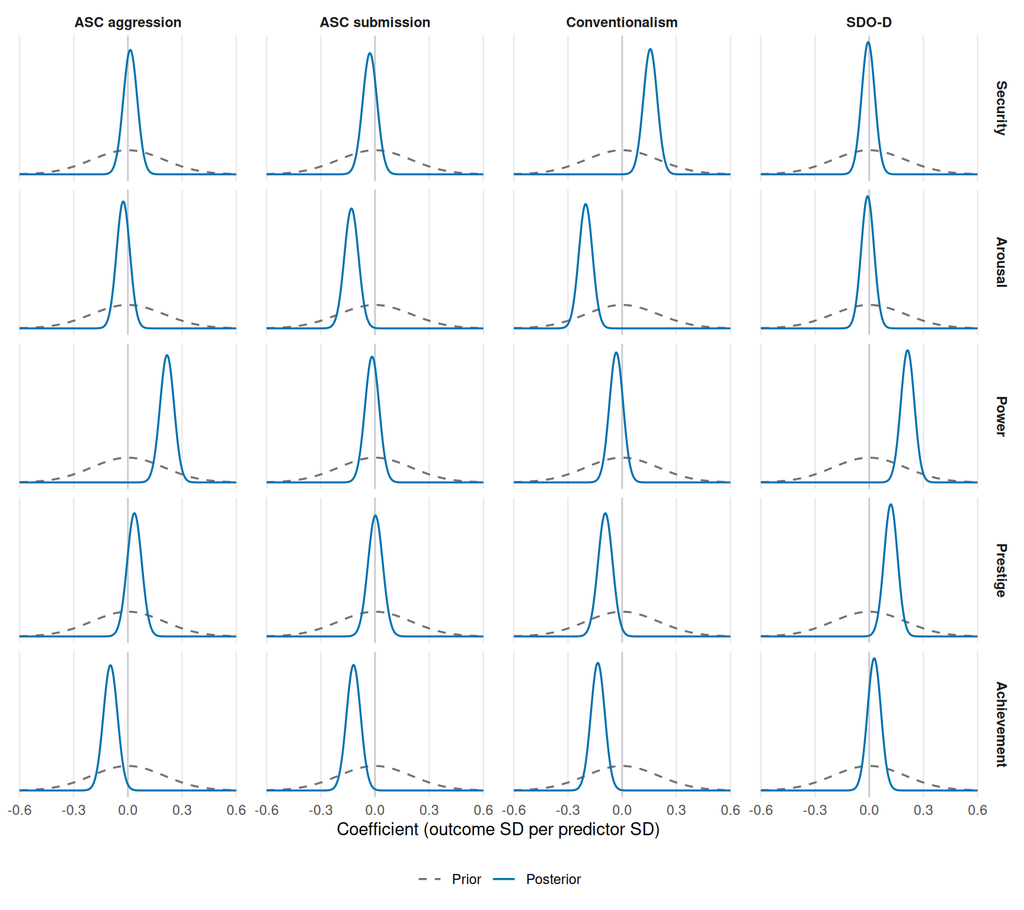

Figure S1: Prior and posterior of each motive coefficient in the four regressions with the preregistered prior.

#### Posterior-Predictive Checks

Table S10 sets the observed minimum, maximum, excess kurtosis and skewness of each facet against the band of the replicated data and gives the one-sided posterior predictive *p*-value of every statistic; the note of that table states the direction of that value, which for the minimum runs opposite to a heavy-tail reading. Figure S2 shows the same fits as densities against the observed distribution. The displayed table focuses on skewness, excess kurtosis, minimum, and maximum. Predictive checks of the mean and standard deviation are retained in the accompanying data file (posterior_predictive_checks.csv). It answers whether data simulated from each fitted model look like the observed facet scores.

| Outcome | Statistic | Observed | Range of 95% of the simulated data sets | P(replicated ≥ observed) |
| --- | --- | --- | --- | --- |
| ASC aggression | minimum | −2.81 | [−4.02, −2.56] | .172 |
|  | maximum | **4.24** | [2.55, 4.06] | .015 |
|  | excess kurtosis | **0.80** | [−0.33, 0.39] | .001 |
|  | skewness | **0.22** | [−0.17, 0.18] | .007 |
| ASC submission | minimum | −2.64 | [−4.03, −2.58] | .049 |
|  | maximum | 3.10 | [2.57, 4.06] | .522 |
|  | excess kurtosis | −0.21 | [−0.31, 0.36] | .881 |
|  | skewness | 0.06 | [−0.18, 0.19] | .262 |
| Conventionalism | minimum | −3.29 | [−4.09, −2.55] | .690 |
|  | maximum | 2.63 | [2.56, 4.02] | .953 |
|  | excess kurtosis | −0.05 | [−0.33, 0.38] | .559 |
|  | skewness | −0.15 | [−0.18, 0.18] | .948 |
| SDO-D | minimum | **−2.21** | [−3.94, −2.52] | < .001 |
|  | maximum | 3.75 | [2.54, 3.94] | .051 |
|  | excess kurtosis | −0.23 | [−0.36, 0.32] | .850 |
|  | skewness | **0.28** | [−0.17, 0.17] | .001 |

*Note.* Range: the central 95% interval of the statistic over the data sets simulated from the fitted model; bold: the observed value lies outside it. P(replicated ≥ observed): share of the simulated data sets whose statistic is at or above the observed value; for the minimum, a value near zero indicates a lighter (more bounded) lower tail.

Table S10: Posterior predictive checks: each observed statistic against the range of the data sets simulated from the fitted model, with the one-sided posterior predictive p-value.

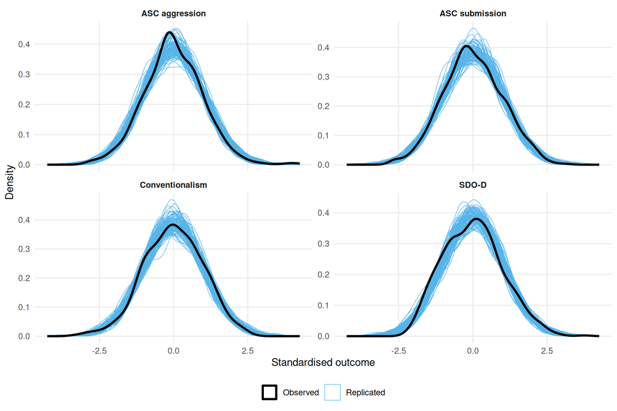

Figure S2: Posterior predictive distributions against the observed distribution of each facet.

#### Refit With Heavier Tails

The Gaussian likelihood is the preregistered choice, and a Student-t refit is a descriptive complement that runs only for a facet whose tail statistic is more extreme than its replicated band on one side. Only ASC aggression met the preregistered rule for heavier-than-normal tails: its maximum (4.24; simulated range [2.55, 4.06]) and its excess kurtosis (0.80; simulated range [−0.33, 0.39]) lay outside the range of 95% of the data sets simulated from the normal model. The refit allowing heavier tails (Student-t errors) therefore ran for ASC aggression only. A refit never changes a verdict of the Results section.

The following observed statistics fell outside the range of 95% of the data sets simulated from the fitted model: the maximum of ASC aggression (above it), the excess kurtosis of ASC aggression (above it), the skewness of ASC aggression (above it), the minimum of SDO-D (above it) and the skewness of SDO-D (above it). The preregistered refit addresses heavy tails only: it replaces the Gaussian likelihood by a Student-t one with a fixed degrees-of-freedom parameter, which widens the tails and does nothing about asymmetry or a bounded response range. A misfit in the skewness of a bounded, standardised Likert score is therefore reported here and not treated, because treating it would mean changing a preregistered likelihood after seeing the data.

Table S11 answers whether the coefficients of ASC aggression change when the model allows heavier tails: each coefficient of the Gaussian model beside the same coefficient of the refit. No refit ran for ASC submission, conventionalism and SDO-D.

| Coefficient | Normal model | Model allowing heavier tails (Student-*t*) |
| --- | --- | --- |
| Security | 0.01 [−0.06, 0.09] | 0.00 [−0.07, 0.07] |
| Arousal | −0.03 [−0.10, 0.05] | −0.02 [−0.09, 0.05] |
| Power | **0****.22** [0.14, 0.29] | **0****.22** [0.15, 0.30] |
| Prestige | 0.04 [−0.04, 0.12] | 0.03 [−0.04, 0.11] |
| Achievement | **−0****.10** [−0.17, −0.02] | **−0****.08** [−0.15, −0.00] |
| Age band | 0.00 [−0.07, 0.07] | 0.02 [−0.05, 0.08] |
| Gender: male | **0****.35** [0.21, 0.49] | **0****.41** [0.28, 0.55] |
| Income band per household member | **−0****.09** [−0.16, −0.02] | **−0****.09** [−0.16, −0.03] |

*Note.* Posterior median [95% CrI]; bold estimate: its interval excludes zero. Student-*t* degrees of freedom: ν fixed at 4 (constant, no tail parameter); scale σ ~ half-normal(0, 0.71).

Table S11: The coefficients of the Gaussian model beside those of the refit allowing heavier tails.

For ASC aggression, the refit allowing heavier tails explained a share of .11 [.07, .15] of the variance (Bayesian R², posterior median with its credible interval), the normal model .12 [.08, .16]; the residual variance of the Student-t model is its scale σ² times ν / (ν − 2), with ν fixed at 4.

### S3.3 Validity Gate

Table S12 answers whether every regression fit sampled reliably enough to be interpreted: the 12 fits of RQ1 under the three priors, the refit allowing heavier tails, the joint model of the five motives and the joint model of RQ2. The preregistration states the diagnostic rules (AP6). All 15 fits had no divergent transition and no transition at the maximum tree depth and passed every check of the validity gate; the 12 normal fits of RQ1 used 699 cases and 1,000 post-warm-up iterations per chain.

| Fit | Smallest bulk ESS | Smallest tail ESS | Largest R̂ | Smallest BFMI |
| --- | --- | --- | --- | --- |
| ASC aggression, skeptical prior (SD 0.10) | 6,404 | 2,939 | 1.003 | 0.96 |
| ASC aggression, primary prior (SD 0.20) | 6,359 | 2,868 | 1.002 | 1.03 |
| ASC aggression, permissive prior (SD 0.40) | 5,839 | 2,650 | 1.003 | 0.95 |
| ASC submission, skeptical prior (SD 0.10) | 6,432 | 2,883 | 1.004 | 1.03 |
| ASC submission, primary prior (SD 0.20) | 6,241 | 2,366 | 1.004 | 1.02 |
| ASC submission, permissive prior (SD 0.40) | 5,950 | 2,700 | 1.002 | 1.04 |
| Conventionalism, skeptical prior (SD 0.10) | 5,877 | 2,612 | 1.002 | 0.92 |
| Conventionalism, primary prior (SD 0.20) | 6,152 | 2,797 | 1.004 | 1.02 |
| Conventionalism, permissive prior (SD 0.40) | 6,348 | 2,785 | 1.002 | 0.98 |
| SDO-D, skeptical prior (SD 0.10) | 5,810 | 2,784 | 1.005 | 1.05 |
| SDO-D, primary prior (SD 0.20) | 5,415 | 2,853 | 1.005 | 0.98 |
| SDO-D, permissive prior (SD 0.40) | 6,271 | 2,916 | 1.004 | 0.98 |
| ASC aggression, refit allowing heavier tails (Student-t) | 6,563 | 2,840 | 1.003 | 0.92 |
| Joint model of the five motives (RQ1) | 4,030 | 2,796 | 1.003 | 0.97 |
| Joint regression of the four facets (RQ2) | 3,517 | 2,815 | 1.003 | 1.03 |

*Note.* Over the population-level coefficients of each fit: ESS, effective sample size, the number of independent draws the chains are worth, in the bulk and in the tails of the posterior; R̂, the agreement between the chains, complete at one; BFMI, the energy diagnostic of the sampler, smallest over the chains. The validity gate of this run requires an ESS of at least 2,000, R̂ of at most 1.010, no divergent transition, no transition at the maximum tree depth and a BFMI of at least 0.20 in every chain. In the joint model of the five motives, the residual correlations, from which the partial correlations come, are included.

Table S12: Sampling diagnostics of every regression fit.

## S4 Bayesian Network Analysis (RQ3)

**Research question.** Which associations between sets remain after conditioning on every other variable in the network?

### S4.1 Full-Data and Bagged Network

The edge decisions of the Results section come from the bagged posterior. This section sets the bagged network against the full-data network, the network fitted once to the whole sample, under the same settings, and reports how stable the decisions are across the resamples. The bagged network is the preregistered estimate; the comparison is descriptive and shows how much the resampling moves the decisions. The bagged and full-data decisions agreed for 22 of 36 edges, and every disagreement became inconclusive after bagging.

Table S13 lists the edges they disagree on; no edge is called present by one and absent by the other. Figure A1 shows, for every edge, how its inclusion probability varies across the bootstrap resamples; Figure S3 plots the two inclusion probabilities against each other, and Figure A2 draws the two graphs side by side. Figure S3 answers how far bagging moves the inclusion probability of each edge: the dashed lines mark the inclusion probabilities at which an edge is present (.909, a Bayes factor of 10) and absent (.091, a Bayes factor of 0.10).

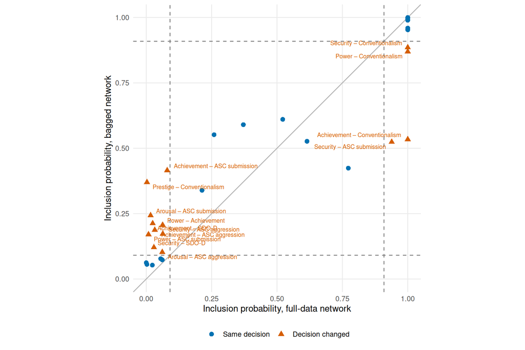

Figure S3: Inclusion probability of every edge in the full-data network against its inclusion probability in the bagged network.

Table S13 answers which edges change their decision between the full-data network and the bagged network, and how often a single resample reaches either threshold for them.

| Edge | Decision: full-data → bagged | Inclusion probability, full-data network | Bayes factor, full-data network | Inclusion probability, bagged network | BF<sub>bagged</sub> | Share of resamples with Bayes factor ≥ 10 | Share of resamples with Bayes factor ≤ 0.10 | Middle 90% of the resamples’ inclusion probabilities |
| --- | --- | --- | --- | --- | --- | --- | --- | --- |
| Achievement – Conventionalism | present → inconclusive | 1.000 | > 1,000 | .534 | 1.15 | .32 | .20 | [.007, 1.000] |
| Security – ASC submission | present → inconclusive | .939 | 15 | .524 | 1.10 | .27 | .17 | [.031, 1.000] |
| Prestige – Conventionalism | absent → inconclusive | .003 | < 0.01 | .370 | 0.59 | .18 | .38 | [.012, 1.000] |
| Achievement – ASC submission | absent → inconclusive | .080 | 0.09 | .415 | 0.71 | .15 | .32 | [.000, 1.000] |
| Arousal – ASC submission | absent → inconclusive | .017 | 0.02 | .243 | 0.32 | .02 | .47 | [.000, .834] |
| Achievement – SDO-D | absent → inconclusive | .025 | 0.03 | .213 | 0.27 | .07 | .53 | [.000, .977] |
| Power – ASC submission | absent → inconclusive | .009 | < 0.01 | .170 | 0.21 | .03 | .60 | [.000, .800] |
| Achievement – ASC aggression | absent → inconclusive | .033 | 0.03 | .187 | 0.23 | .05 | .53 | [.000, .811] |
| Power – Achievement | absent → inconclusive | .063 | 0.07 | .207 | 0.26 | .03 | .45 | [.000, .771] |
| Power – Conventionalism | present → inconclusive | 1.000 | > 1,000 | .870 | 6.68 | .70 | .02 | [.415, 1.000] |
| Security – Conventionalism | present → inconclusive | 1.000 | > 1,000 | .885 | 7.72 | .70 | .00 | [.342, 1.000] |
| Security – ASC aggression | absent → inconclusive | .063 | 0.07 | .173 | 0.21 | .03 | .63 | [.000, .874] |
| Security – SDO-D | absent → inconclusive | .029 | 0.03 | .121 | 0.14 | .00 | .67 | [.000, .476] |
| Arousal – ASC aggression | absent → inconclusive | .061 | 0.07 | .103 | 0.11 | .00 | .68 | [.000, .439] |

*Note.* Full-data network: the network fitted once to the whole sample. BF<sub>bagged</sub>: bagged Bayes factor. Shares: the share of the successful resamples whose own inclusion probability reaches .909 (Bayes factor 10, present) or falls to .091 (Bayes factor 0.10, absent). A Bayes factor above 100 is shown as the power of ten it exceeds, one below 0.01 as the power of ten it falls below, at most to the limit that 1,500 sampled networks can resolve.

Table S13: The edges whose decision differs between the full-data network and the bagged network.

### S4.2 Edge-Prior Sensitivity

The classifications also depend on the prior probability that an edge belongs in the graph, because the rule compares posterior odds with prior odds. The network was therefore refitted on all rows of the network sample at each of .25, .50, .75, with the decision thresholds unchanged. Most edges keep their classification across the unbagged full-data refits, and the classification of 9 edges depends on it: security – ASC aggression; security – ASC submission; arousal – prestige; arousal – SDO-D; power – achievement; prestige – ASC submission; prestige – conventionalism; achievement – ASC submission; achievement – conventionalism. Stability of the bagged classifications across edge priors is not evaluated by this comparison. This comparison is descriptive: the reported classifications are the bagged ones at .50. Every edge’s result under each prior is reported in Table S14. The table answers whether the decision of the full-data network depends on the assumed prior probability that an edge exists.

| Edge | Prior inclusion probability .25 | Prior inclusion probability .50 | Prior inclusion probability .75 |
| --- | --- | --- | --- |
| Security – Arousal | present (> 1,000) | present (> 1,000) | present (> 100) |
| Security – Power | inconclusive (0.43) | inconclusive (1.09) | inconclusive (1.06) |
| Security – Prestige | inconclusive (0.31) | inconclusive (0.59) | inconclusive (0.95) |
| Security – Achievement | present (> 1,000) | present (> 1,000) | present (> 100) |
| Security – ASC aggression | inconclusive (0.18) | absent (0.07) | absent (0.09) |
| Security – ASC submission | inconclusive (8.66) | present (15) | present (> 100) |
| Security – Conventionalism | present (> 1,000) | present (> 1,000) | present (> 100) |
| Security – SDO-D | absent (0.09) | absent (0.03) | absent (0.04) |
| Arousal – Power | inconclusive (0.19) | inconclusive (0.35) | inconclusive (0.61) |
| Arousal – Prestige | present (18) | inconclusive (3.40) | inconclusive (0.43) |
| Arousal – Achievement | inconclusive (0.49) | inconclusive (0.27) | inconclusive (0.27) |
| Arousal – ASC aggression | absent (0.03) | absent (0.07) | absent (0.02) |
| Arousal – ASC submission | absent (< 0.01) | absent (0.02) | absent (0.04) |
| Arousal – Conventionalism | present (> 1,000) | present (> 1,000) | present (> 100) |
| Arousal – SDO-D | inconclusive (0.20) | absent (0.07) | absent (0.04) |
| Power – Prestige | present (> 1,000) | present (> 1,000) | present (> 100) |
| Power – Achievement | absent (0.06) | absent (0.07) | inconclusive (0.11) |
| Power – ASC aggression | present (> 1,000) | present (> 1,000) | present (> 100) |
| Power – ASC submission | absent (0.02) | absent (< 0.01) | absent (0.04) |
| Power – Conventionalism | present (> 1,000) | present (> 1,000) | present (> 100) |
| Power – SDO-D | present (> 1,000) | present (> 1,000) | present (> 100) |
| Prestige – Achievement | present (> 1,000) | present (> 1,000) | present (> 100) |
| Prestige – ASC aggression | absent (< 0.01) | absent (< 0.01) | absent (0.02) |
| Prestige – ASC submission | inconclusive (0.18) | absent (0.06) | absent (0.05) |
| Prestige – Conventionalism | absent (< 0.01) | absent (< 0.01) | inconclusive (0.25) |
| Prestige – SDO-D | inconclusive (0.93) | inconclusive (1.60) | inconclusive (0.86) |
| Achievement – ASC aggression | absent (< 0.01) | absent (0.03) | absent (0.05) |
| Achievement – ASC submission | inconclusive (0.73) | absent (0.09) | absent (0.09) |
| Achievement – Conventionalism | present (59) | present (> 1,000) | inconclusive (3.00) |
| Achievement – SDO-D | absent (0.06) | absent (0.03) | absent (0.09) |
| ASC aggression – ASC submission | present (> 1,000) | present (> 1,000) | present (> 100) |
| ASC aggression – Conventionalism | present (> 1,000) | present (> 1,000) | present (> 100) |
| ASC aggression – SDO-D | present (> 1,000) | present (> 1,000) | present (> 100) |
| ASC submission – Conventionalism | present (> 1,000) | present (> 1,000) | present (> 100) |
| ASC submission – SDO-D | absent (< 0.01) | absent (0.02) | absent (0.03) |
| Conventionalism – SDO-D | absent (< 0.01) | absent (< 0.001) | absent (< 0.01) |

*Note.* Each cell: the decision of the full-data network, the network fitted once to the whole sample, at that prior probability that an edge exists, with its inclusion Bayes factor in parentheses. The bagged network’s decisions at the preregistered .50 are in the three network tables of the Results. A Bayes factor above 100 is shown as the power of ten it exceeds, one below 0.01 as the power of ten it falls below, at most to the limit that 1,500 sampled networks can resolve.

Table S14: Decision of the full-data network for every edge under each prior inclusion probability.

## S5 Exploratory Factor Analyses (SRQ1)

**Research question.** How distinctly are the five social motives and the four facets of authoritarian orientation represented when their complete item sets are examined together?

Reliability and dimensionality answer different questions: omega and alpha describe how consistently a scale’s items vary together, whereas the exploratory analyses ask how many dimensions the items suggest. Each of the nine scales is analysed on its own, and the five item sets of the analysis plan are analysed together: each names the scales analysed together, and the number of factors expected is the number of scales it holds. The number of factors each of the nine criteria suggests, the correspondence between the estimated factors and the intended scales, the loading clarity and the item membership are in Section A4.

The solutions use polychoric correlations, WLS extraction and the primary oblimin rotation. Every item is assigned to the factor with its largest absolute loading. The complete loading matrices of every solution are in the data file efa_loadings.csv, and the complete item membership of every solution in efa_membership.csv.

For every examined solution, the single-scale solutions included, Table S15 gives the share of the item variance each factor accounts for and the running total. It answers how much of the item variance each solution and each of its factors accounts for.

| Scale or item set | Solution | Proportion of variance by factor | Total |
| --- | --- | --- | --- |
| Security | 1 factor (one per scale) | — | .39 |
| Arousal | 1 factor (one per scale) | — | .44 |
| Power | 1 factor (one per scale) | — | .43 |
| Prestige | 1 factor (one per scale) | — | .42 |
| Achievement | 1 factor (one per scale) | — | .40 |
| ASC aggression | 1 factor (one per scale) | — | .40 |
| ASC submission | 1 factor (one per scale) | — | .41 |
| Conventionalism | 1 factor (one per scale) | — | .42 |
| SDO-D | 1 factor (one per scale) | — | .42 |
| ASC | 3 factors (one per scale) | ASC aggression .13; ASC submission .14; Conventionalism .15 | .42 |
|  | 1 factor (suggested by 1 of 9 criteria) | — | .25 |
|  | 2 factors (suggested by 1 of 9 criteria) | Factor 1 (ASC submission and conventionalism) .22; Factor 2 (ASC aggression) .13 | .35 |
| DoPL-6 (dominance and prestige) | 2 factors (one per scale) | Power .21; Prestige .21 | .43 |
| UMS-6 (intimacy and achievement) | 2 factors (one per scale) | Security .20; Achievement .20 | .40 |
| All social motive scales | 5 factors (one per scale) | Security .08; Arousal .09; Power .09; Prestige .09; Achievement .08 | .42 |
|  | 1 factor (suggested by 1 of 9 criteria) | — | .17 |
| ASC and SDO-D | 4 factors (one per scale) | ASC aggression .09; ASC submission .10; Conventionalism .10; SDO-D .12 | .42 |
|  | 2 factors (suggested by 2 of 9 criteria) | Factor 1 (ASC submission and conventionalism) .17; Factor 2 (ASC aggression and SDO-D) .15 | .32 |
|  | 3 factors (suggested by 1 of 9 criteria) | Factor 1 (ASC submission and conventionalism) .15; Factor 2 (SDO-D) .12; Factor 3 (ASC aggression) .09 | .37 |

*Note.* Proportion of the item variance each factor accounts for, in the primary rotation, factors in the order of the variance they explain; an em dash marks a solution of one factor, whose share is the total. A factor is named after the scale whose items it carries where the solution holds one factor per scale; otherwise the factors are numbered, with the scales each carries.

Table S15: Variance explained by every examined solution, in the primary rotation.